# Anexo I.- Fase de Preprocesado y Feature Engineering

Mª Antonia Mira Paz

8/22/2021

# 1 Análisis descriptivo de los datos

Para obtener modelos más precisos es muy importante depurar las variables predictoras. Así que en esta primera fase , estudiaremos la naturaleza de las variables, detectaremos los datos erróneos y veremos las distribuciones de las variables.

Empezaré por establecer nuestro directorio de trabajo, cargar las funciones y paquetes que vamos a utilizar.

```r
#Fijo nuestro directorio de trabajo
setwd('./')

#Cargo las funciones necesarias
source("./Funciones_R.R")
```

Cargo las librerias necesarias

```r
rm(list = ls())
install.packages("r package", repos = "http://cran.us.r-project.org")
suppressPackageStartupMessages({
  library(data.table)
  library(dplyr)
  library(caret)
  library(scales)
  library(ggplot2)
  library(gridExtra)
  library(stringi)
  library(stringr)
  library(dataPreparation)
  library(knitr)
  library(kableExtra)
  library(ggpubr)
  library(tictoc)
  library(ggeasy)
  library(lubridate)
  library(inspectdf)
  library(fastDummies)
  library(e1071)
  library(MLmetrics)
  library(ranger)
  library(caTools)
  library(h2o)
  library(questionr)
  library(corrplot)
  library(funModeling)
})
```

A continuación, cargo los datos

```r
datIn <- as.data.frame(fread("datos_atentados.csv"), nThread = 2)
```

Realizo una primera inspección de los datos

```r
#Compruebo la dimensión de los datos cargados
dim(datIn)
```

```
## [1] 191464     66
```

```r
#Observo los seis primeros registros de cada variable
head(datIn)
```

```
##        eventid iyear imonth iday extended resolution country        country_txt
## 1 197000000001  1970      7    2        0                 58 Dominican Republic
## 2 197000000002  1970      0    0        0                130             Mexico
## 3 197001000001  1970      1    0        0                160        Philippines
## 4 197001000002  1970      1    0        0                 78             Greece
## 5 197001000003  1970      1    0        0                101              Japan
## 6 197001010002  1970      1    1        0                217      United States
##   region                  region_txt          city latitude longitude vicinity
## 1      2 Central America & Caribbean Santo Domingo 18.45679 -69.95116        0
## 2      1               North America   Mexico city 19.37189 -99.08662        0
## 3      5              Southeast Asia       Unknown 15.47860 120.59974        0
## 4      8              Western Europe        Athens 37.99749  23.76273        0
## 5      4                   East Asia       Fukouka 33.58041 130.39636        0
## 6      1               North America         Cairo 37.00511 -89.17627        0
##   crit1 crit2 crit3 doubtterr alternative alternative_txt multiple success
```

[output cut: 62 more lines]

El dataset contiene **191464 registros** y **66 variables predictoras**.

En esta primera inspección, veo que **existen variables** con **espacios** en **blanco**, por lo tanto, deberemos **sustituir** los valores en blanco **por** valores **missing**, esto lo haré en el apartado de exploración de los datos.

Hay una variable que es **‘eventid’**, que contiene el id de cada atentado, que **no necesitaremos**.

## 1.1 Limpieza de los datos cargados

Limpio los datos y examino las clases del conjunto de entrada.

```r
#Separo la variable 'eventid' del resto
datIn_noid <- datIn[,2:(ncol(datIn))]
#Compruebo que los nombres de las columnas sean correctos, es decir, que no tengan espacios en blanco
names(datIn_noid)
```

```
##  [1] "iyear"              "imonth"             "iday"
##  [4] "extended"           "resolution"         "country"
##  [7] "country_txt"        "region"             "region_txt"
## [10] "city"               "latitude"           "longitude"
## [13] "vicinity"           "crit1"              "crit2"
## [16] "crit3"              "doubtterr"          "alternative"
## [19] "alternative_txt"    "multiple"           "success"
## [22] "suicide"            "attacktype1"        "attacktype1_txt"
## [25] "attacktype2"        "attacktype2_txt"    "attacktype3"
## [28] "attacktype3_txt"    "targtype1"          "targtype1_txt"
## [31] "natlty1"            "natlty1_txt"        "individual"
## [34] "nperps"             "nperpcap"           "claimed"
## [37] "claimmode"          "claimmode_txt"      "compclaim"
## [40] "weaptype1"          "weaptype1_txt"      "nkill"
## [43] "nkillter"           "nwound"             "nwoundte"
## [46] "property"           "propextent"         "propextent_txt"
## [49] "propvalue"          "ishostkid"          "nhostkid"
## [52] "nhours"             "ndays"              "divert"
## [55] "kidhijcountry"      "ransom"             "ransomamt"
## [58] "ransompaid"         "hostkidoutcome"     "hostkidoutcome_txt"
## [61] "nreleased"          "INT_LOG"            "INT_IDEO"
## [64] "INT_MISC"           "INT_ANY"
```

```r
# Hago una inspección inicial
summary(datIn_noid)
```

```
##      iyear          imonth            iday          extended
##  Min.   :1970   Min.   : 0.000   Min.   : 0.00   Min.   :0.00000
##  1st Qu.:1991   1st Qu.: 4.000   1st Qu.: 8.00   1st Qu.:0.00000
##  Median :2010   Median : 6.000   Median :15.00   Median :0.00000
##  Mean   :2003   Mean   : 6.463   Mean   :15.51   Mean   :0.04748
##  3rd Qu.:2015   3rd Qu.: 9.000   3rd Qu.:23.00   3rd Qu.:0.00000
##  Max.   :2018   Max.   :12.000   Max.   :31.00   Max.   :1.00000
##
##   resolution           country       country_txt            region
##  Length:191464      Min.   :   4.0   Length:191464      Min.   : 1.000
##  Class :character   1st Qu.:  78.0   Class :character   1st Qu.: 6.000
##  Mode  :character   Median :  98.0   Mode  :character   Median : 7.000
##                     Mean   : 131.3                      Mean   : 7.205
##                     3rd Qu.: 160.0                      3rd Qu.:10.000
##                     Max.   :1004.0                      Max.   :12.000
##
##   region_txt            city              latitude        longitude
##  Length:191464      Length:191464      Min.   :-53.16   Min.   :-176.176
##  Class :character   Class :character   1st Qu.: 11.28   1st Qu.:   7.053
##  Mode  :character   Mode  :character   Median : 31.45   Median :  43.471
##                                        Mean   : 23.46   Mean   :  28.902
##                                        3rd Qu.: 34.62   3rd Qu.:  68.783
##                                        Max.   : 74.63   Max.   : 179.367
##                                        NA's   :4580     NA's   :4581
##     vicinity            crit1            crit2            crit3
##  Min.   :-9.00000   Min.   :0.0000   Min.   :0.0000   Min.   :0.0000
##  1st Qu.: 0.00000   1st Qu.:1.0000   1st Qu.:1.0000   1st Qu.:1.0000
##  Median : 0.00000   Median :1.0000   Median :1.0000   Median :1.0000
##  Mean   : 0.06915   Mean   :0.9884   Mean   :0.9931   Mean   :0.8728
##  3rd Qu.: 0.00000   3rd Qu.:1.0000   3rd Qu.:1.0000   3rd Qu.:1.0000
##  Max.   : 1.00000   Max.   :1.0000   Max.   :1.0000   Max.   :1.0000
##
##    doubtterr        alternative     alternative_txt       multiple
##  Min.   :-9.0000   Min.   :1.0      Length:191464      Min.   :0.0000
##  1st Qu.: 0.0000   1st Qu.:1.0      Class :character   1st Qu.:0.0000
##  Median : 0.0000   Median :1.0      Mode  :character   Median :0.0000
##  Mean   :-0.4858   Mean   :1.3                         Mean   :0.1394
##  3rd Qu.: 0.0000   3rd Qu.:1.0                         3rd Qu.:0.0000
##  Max.   : 1.0000   Max.   :5.0                         Max.   :1.0000
##                    NA's   :160394
```

[output cut: 81 more lines]

```
##  Min.   : -99.00   Min.   :-9.000   Min.   :-9.000   Min.   :-9.00000
##  1st Qu.: -99.00   1st Qu.:-9.000   1st Qu.:-9.000   1st Qu.: 0.00000
##  Median :   0.00   Median :-9.000   Median :-9.000   Median : 0.00000
##  Mean   : -29.82   Mean   :-4.522   Mean   :-4.439   Mean   : 0.08895
##  3rd Qu.:   1.00   3rd Qu.: 0.000   3rd Qu.: 0.000   3rd Qu.: 0.00000
##  Max.   :2912.00   Max.   : 1.000   Max.   : 1.000   Max.   : 1.00000
##  NA's   :180010
##     INT_ANY
##  Min.   :-9.000
##  1st Qu.:-9.000
##  Median : 0.000
##  Mean   :-3.931
##  3rd Qu.: 0.000
##  Max.   : 1.000
##
```

```r
str(datIn_noid)
```

```
## 'data.frame':    191464 obs. of  65 variables:
##  $ iyear             : int  1970 1970 1970 1970 1970 1970 1970 1970 1970 1970 ...
##  $ imonth            : int  7 0 1 1 1 1 1 1 1 1 ...
##  $ iday              : int  2 0 0 0 0 1 2 2 2 3 ...
##  $ extended          : int  0 0 0 0 0 0 0 0 0 0 ...
##  $ resolution        : chr  "" "" "" "" ...
##  $ country           : int  58 130 160 78 101 217 218 217 217 217 ...
##  $ country_txt       : chr  "Dominican Republic" "Mexico" "Philippines" "Greece" ...
##  $ region            : int  2 1 5 8 4 1 3 1 1 1 ...
##  $ region_txt        : chr  "Central America & Caribbean" "North America" "Southeast Asia" "Western Europe" ...
##  $ city              : chr  "Santo Domingo" "Mexico city" "Unknown" "Athens" ...
##  $ latitude          : num  18.5 19.4 15.5 38 33.6 ...
##  $ longitude         : num  -70 -99.1 120.6 23.8 130.4 ...
##  $ vicinity          : int  0 0 0 0 0 0 0 0 0 0 ...
##  $ crit1             : int  1 1 1 1 1 1 1 1 1 1 ...
```

[output cut: 51 more lines]

- En cuanto a la **naturaleza de las variables**, podemos observar que R ha considerado **muchas** de las **variables tipo factor**, porque así se definen en la descripción de las variables del Codebook, **como numéricas**, incluida ‘success’, nuestra variable objetivo. Por lo tanto, tendremos que **transformarlas** al **tipo correcto**.
- Podemos ver que hay **variables** con el **mismo nombre**, con ’_txt’ y sin ’_txt’. Si revisamos la definición de estas variables en el ‘Code Book’, podemos ver que hay variables que contienen la **misma información**, éstas estan tanto en formato ‘character’, como en formato código. Por lo que, sólo **dejaré** en el **dataset** aquellas variables repetidas que estén **codificadas**.
- Observar también que, la variable **‘resolution’** está codificada como character, sin embargo, contiene la fecha en el que el incidente se resolvió si la duración del atentado fue mayor de 24 horas. Por lo que habrá que **corregir** la **clase** de la variable a **tipo ‘Date’**.

A continuación, **corrijo el tipo de las variables** comentadas anteriormente:

```r
#Modifico las variables que no son numéricas al tipo correcto (factor)

datIn_noid$extended <- as.factor(ifelse(datIn_noid$extended == 1, "Yes", "No"))

datIn_noid$vicinity <- as.factor(ifelse(datIn_noid$vicinity == 1,"Yes", ifelse(datIn_noid$vicinity == 0, "No", "Unknown")))

datIn_noid$crit1 <- as.factor(ifelse(datIn_noid$crit1 == 1, "Yes", "No"))

datIn_noid$crit2 <- as.factor(ifelse(datIn_noid$crit2 == 1, "Yes", "No"))

datIn_noid$crit3 <- as.factor(ifelse(datIn_noid$crit3 == 1, "Yes", "No"))

datIn_noid$doubtterr <- as.factor(ifelse(datIn_noid$doubtterr == 1,"Yes", ifelse(datIn_noid$doubtterr == 0, "No", "Unknown")))

datIn_noid$alternative <- as.factor(ifelse(datIn_noid$alternative == 1,"Insurgency/Guerilla Action", ifelse(datIn_noid$alternative == 2, "Other Crime Type", ifelse(datIn_noid$alternative == 3, "Inter/Intra-Group Conflict", ifelse(datIn_noid$alternative == 4, "Lack of Intentionality","State Actors")))))

datIn_noid$multiple <- as.factor(ifelse(datIn_noid$multiple == 1, "Yes", "No"))

datIn_noid$success <- as.factor(ifelse(datIn_noid$success == 1, "Yes", "No"))

datIn_noid$suicide <- as.factor(ifelse(datIn_noid$suicide == 1, "Yes", "No"))

datIn_noid$attacktype1 <- as.factor(ifelse(datIn_noid$attacktype1 == 1,"ASSASSINATION", ifelse(datIn_noid$attacktype1 == 2, "ARMED ASSAULT", ifelse(datIn_noid$attacktype1 == 3, "BOMBING/EXPLOSION", ifelse(datIn_noid$attacktype1 == 4, "HIJACKING",
ifelse(datIn_noid$attacktype1 == 5, "HOSTAGE TAKING (BARRICADE INCIDENT)",
ifelse(datIn_noid$attacktype1 == 6, "HOSTAGE TAKING (KIDNAPPING)",
ifelse(datIn_noid$attacktype1 == 7, "FACILITY / INFRASTRUCTURE ATTACK",   ifelse(datIn_noid$attacktype1 == 8, "UNARMED ASSAULT","Unknown")))))))))

datIn_noid$attacktype2 <- as.factor(ifelse(datIn_noid$attacktype2 == 1,"ASSASSINATION", ifelse(datIn_noid$attacktype2 == 2, "ARMED ASSAULT", ifelse(datIn_noid$attacktype2 == 3, "BOMBING/EXPLOSION", ifelse(datIn_noid$attacktype2 == 4, "HIJACKING",
ifelse(datIn_noid$attacktype2 == 5, "HOSTAGE TAKING (BARRICADE INCIDENT)",
ifelse(datIn_noid$attacktype2 == 6, "HOSTAGE TAKING (KIDNAPPING)",
ifelse(datIn_noid$attacktype2 == 7, "FACILITY / INFRASTRUCTURE ATTACK",   ifelse(datIn_noid$attacktype2 == 8, "UNARMED ASSAULT","Unknown")))))))))

datIn_noid$attacktype3 <- as.factor(ifelse(datIn_noid$attacktype3 == 1,"ASSASSINATION", ifelse(datIn_noid$attacktype3 == 2, "ARMED ASSAULT", ifelse(datIn_noid$attacktype3 == 3, "BOMBING/EXPLOSION", ifelse(datIn_noid$attacktype3 == 4, "HIJACKING",
ifelse(datIn_noid$attacktype3 == 5, "HOSTAGE TAKING (BARRICADE INCIDENT)",
ifelse(datIn_noid$attacktype3 == 6, "HOSTAGE TAKING (KIDNAPPING)",
ifelse(datIn_noid$attacktype3 == 7, "FACILITY / INFRASTRUCTURE ATTACK",   ifelse(datIn_noid$attacktype3 == 8, "UNARMED ASSAULT","Unknown")))))))))

datIn_noid$targtype1 <- as.factor(
ifelse(datIn_noid$targtype1 == 1,"BUSINESS",
ifelse(datIn_noid$targtype1 == 2, "GOVERNMENT (GENERAL)", ifelse(datIn_noid$targtype1 == 3, "POLICE",
ifelse(datIn_noid$targtype1 == 4, "MILITARY",
ifelse(datIn_noid$targtype1 == 5, "ABORTION RELATED",
ifelse(datIn_noid$targtype1 == 6, "AIRPORTS",
ifelse(datIn_noid$targtype1 == 7, "GOVERNMENT (DIPLOMATIC)",
ifelse(datIn_noid$targtype1 == 8, "EDUCATIONAL INSTITUTION",
ifelse(datIn_noid$targtype1 == 9, "FOOD OR WATER SUPPLY",    ifelse(datIn_noid$targtype1 == 10, "JOURNALISTS",
ifelse(datIn_noid$targtype1 == 11, "MARITIME",
ifelse(datIn_noid$targtype1 == 12, "NGO",
ifelse(datIn_noid$targtype1 == 13, "OTHER",
ifelse(datIn_noid$targtype1 == 14, "PRIVATE CITIZENS & PROPERTY",
ifelse(datIn_noid$targtype1 == 15, "RELIGIOUS FIGURES",  ifelse(datIn_noid$targtype1 == 16, "TELECOMMUNICATION",
ifelse(datIn_noid$targtype1 == 17, "TERRORISTS/NON-STATE MILITIAS",  ifelse(datIn_noid$targtype1 == 18, "TOURISTS",
ifelse(datIn_noid$targtype1 == 19, "TRANSPORTATION",  ifelse(datIn_noid$targtype1 == 20, "Unknown",
ifelse(datIn_noid$targtype1 == 21, "UTILITIES","VIOLENT POLITICAL PARTIES"))))))))))))))))))))))

datIn_noid$individual <- as.factor(ifelse(datIn_noid$individual == 1, "Yes", "No"))

datIn_noid$claimed <- as.factor(ifelse(datIn_noid$vicinity == 1,"Yes", ifelse(datIn_noid$vicinity == 0, "No", "Unknown")))

datIn_noid$claimmode <- as.factor(
ifelse(datIn_noid$claimmode == 1,"Letter",
ifelse(datIn_noid$claimmode == 2, "Call (post-incident)", ifelse(datIn_noid$claimmode == 3, "Call (pre-incident)",
ifelse(datIn_noid$claimmode == 4, "E-mail",
ifelse(datIn_noid$claimmode == 5, "Note left at scene",
ifelse(datIn_noid$claimmode == 6, "Video",
ifelse(datIn_noid$claimmode == 7, "Posted to website, blog, social media",
ifelse(datIn_noid$claimmode == 8, "Personal claim",
ifelse(datIn_noid$claimmode == 9, "Other","Unknown"))))))))))

datIn_noid$compclaim <- as.factor(ifelse(datIn_noid$compclaim == 1,"Yes", ifelse(datIn_noid$compclaim == 0, "No", "Unknown")))

datIn_noid$weaptype1 <- as.factor(
ifelse(datIn_noid$weaptype1 == 1,"Biological",
ifelse(datIn_noid$weaptype1 == 2, "Chemical",
ifelse(datIn_noid$weaptype1 == 3, "Radiological",
ifelse(datIn_noid$weaptype1 == 4, "Nuclear",
ifelse(datIn_noid$weaptype1 == 5, "Firearms",
ifelse(datIn_noid$weaptype1 == 6, "Explosives",
ifelse(datIn_noid$weaptype1 == 7, "Fake Weapons",
ifelse(datIn_noid$weaptype1 == 8, "Incendiary",
ifelse(datIn_noid$weaptype1 == 9, "Melee",
ifelse(datIn_noid$weaptype1 == 10, "Vehicle",
ifelse(datIn_noid$weaptype1 == 11, "Sabotage Equipment",
ifelse(datIn_noid$weaptype1 == 12, "Other","Unknown")))))))))))))

datIn_noid$property <- as.factor(ifelse(datIn_noid$property == 1,"Yes", ifelse(datIn_noid$property == 0, "No", "Unknown")))

datIn_noid$propextent <- as.factor(
ifelse(datIn_noid$propextent == 1,"Catastrophic (likely ≥ $1 billion)",
ifelse(datIn_noid$propextent == 2, "Major (likely ≥ $1 million but < $1 billion)",
ifelse(datIn_noid$propextent == 3, "Minor (likely < $1 million)","Unknown"))))

datIn_noid$ishostkid <- as.factor(ifelse(datIn_noid$ishostkid == 1,"Yes", ifelse(datIn_noid$ishostkid == 0, "No", "Unknown")))

datIn_noid$ransom <- as.factor(ifelse(datIn_noid$ransom == 1,"Yes", ifelse(datIn_noid$ransom == 0, "No", "Unknown")))

datIn_noid$hostkidoutcome <- as.factor(
ifelse(datIn_noid$hostkidoutcome == 1,"Attempted Rescue",
ifelse(datIn_noid$hostkidoutcome == 2, "Hostage(s) released by perpetrators",
ifelse(datIn_noid$hostkidoutcome == 3, "Hostage(s) escaped",
ifelse(datIn_noid$hostkidoutcome == 4, "Hostage(s) killed",
ifelse(datIn_noid$hostkidoutcome == 5, "Successful Rescue",
ifelse(datIn_noid$hostkidoutcome == 6, "Combination","Unknown")))))))

datIn_noid$INT_LOG <- as.factor(ifelse(datIn_noid$INT_LOG == 1,"Yes", ifelse(datIn_noid$INT_LOG == 0, "No", "Unknown")))

datIn_noid$INT_IDEO <- as.factor(ifelse(datIn_noid$INT_IDEO == 1,"Yes", ifelse(datIn_noid$INT_IDEO == 0, "No", "Unknown")))

datIn_noid$INT_MISC <- as.factor(ifelse(datIn_noid$INT_MISC == 1,"Yes", ifelse(datIn_noid$INT_MISC == 0, "No", "Unknown")))

datIn_noid$INT_ANY <- as.factor(ifelse(datIn_noid$INT_ANY == 1,"Yes", ifelse(datIn_noid$INT_ANY == 0, "No", "Unknown")))

#Transformo la variable 'resolution' como Date
datIn_noid$fe_resolution <- mdy(datIn_noid$resolution)
#Quito la variable original 'resolution'
datIn_noid$resolution <- NULL

#Copio los datos
datIn_noid_notxt <- copy(datIn_noid)
#Elimino del dataset copiado las variables terminadas en _txt
datIn_noid_notxt$country_txt <- NULL
datIn_noid_notxt$region_txt <- NULL
datIn_noid_notxt$alternative_txt <- NULL
datIn_noid_notxt$attacktype1_txt <- NULL
datIn_noid_notxt$attacktype2_txt <- NULL
datIn_noid_notxt$attacktype3_txt <- NULL
datIn_noid_notxt$targtype1_txt <- NULL
datIn_noid_notxt$natlty1_txt <- NULL
datIn_noid_notxt$claimmode_txt <- NULL
datIn_noid_notxt$weaptype1_txt <- NULL
datIn_noid_notxt$propextent_txt <- NULL
datIn_noid_notxt$hostkidoutcome_txt <- NULL
```

Comprobamos si los cambios que hemos hecho en cuanto a la naturaleza de las variables se han realizado correctamente.

```r
#Obtenemos de nuevo la estructura de los datos
str(datIn_noid_notxt)
```

```
## 'data.frame':    191464 obs. of  53 variables:
##  $ iyear         : int  1970 1970 1970 1970 1970 1970 1970 1970 1970 1970 ...
##  $ imonth        : int  7 0 1 1 1 1 1 1 1 1 ...
##  $ iday          : int  2 0 0 0 0 1 2 2 2 3 ...
##  $ extended      : Factor w/ 2 levels "No","Yes": 1 1 1 1 1 1 1 1 1 1 ...
##  $ country       : int  58 130 160 78 101 217 218 217 217 217 ...
##  $ region        : int  2 1 5 8 4 1 3 1 1 1 ...
##  $ city          : chr  "Santo Domingo" "Mexico city" "Unknown" "Athens" ...
##  $ latitude      : num  18.5 19.4 15.5 38 33.6 ...
##  $ longitude     : num  -70 -99.1 120.6 23.8 130.4 ...
##  $ vicinity      : Factor w/ 3 levels "No","Unknown",..: 1 1 1 1 1 1 1 1 1 1 ...
##  $ crit1         : Factor w/ 2 levels "No","Yes": 2 2 2 2 2 2 2 2 2 2 ...
##  $ crit2         : Factor w/ 2 levels "No","Yes": 2 2 2 2 2 2 2 2 2 2 ...
##  $ crit3         : Factor w/ 2 levels "No","Yes": 2 2 2 2 2 2 2 2 2 2 ...
##  $ doubtterr     : Factor w/ 3 levels "No","Unknown",..: 1 1 1 1 2 1 1 3 1 1 ...
```

[output cut: 39 more lines]

Podemos comprobar que los **cambios** en los **tipos** de las variables se han modificado **correctamente**.

## 1.2 Exploración de los datos

**Valores en blanco**

Antes de comenzar a explorar los datos, pude comprobar en la inspección inicial la existencia de valores en blanco en algunas variables, por lo tanto, antes de continuar, sustituiré los **espacios en blanco** de las variables **por valores missings**.

```r
datIn_noid_notxt[datIn_noid_notxt==""] <- NA
```

Compruebo que **no** existen **valores** en **blanco**.

```r
head(datIn_noid_notxt)
```

```
##   iyear imonth iday extended country region          city latitude longitude
## 1  1970      7    2       No      58      2 Santo Domingo 18.45679 -69.95116
## 2  1970      0    0       No     130      1   Mexico city 19.37189 -99.08662
## 3  1970      1    0       No     160      5       Unknown 15.47860 120.59974
## 4  1970      1    0       No      78      8        Athens 37.99749  23.76273
## 5  1970      1    0       No     101      4       Fukouka 33.58041 130.39636
## 6  1970      1    1       No     217      1         Cairo 37.00511 -89.17627
##   vicinity crit1 crit2 crit3 doubtterr alternative multiple success suicide
## 1       No   Yes   Yes   Yes        No        <NA>       No     Yes      No
## 2       No   Yes   Yes   Yes        No        <NA>       No     Yes      No
## 3       No   Yes   Yes   Yes        No        <NA>       No     Yes      No
## 4       No   Yes   Yes   Yes        No        <NA>       No     Yes      No
## 5       No   Yes   Yes   Yes   Unknown        <NA>       No     Yes      No
## 6       No   Yes   Yes   Yes        No        <NA>       No     Yes      No
##                        attacktype1 attacktype2 attacktype3
```

[output cut: 41 more lines]

```r
#Guardo los datos para utlizarlos en el documento final
datos_final <- copy(datIn_noid_notxt)
fwrite(datos_final, 'datos_final.csv')
```

Puedo verificar que en variables, como **‘kidhijcountry’** o **‘alternative’**, antes había espacios en blanco y ahora aparecen como **‘NA’**.

### 1.2.1 Exploración de los niveles en las variables categóricas

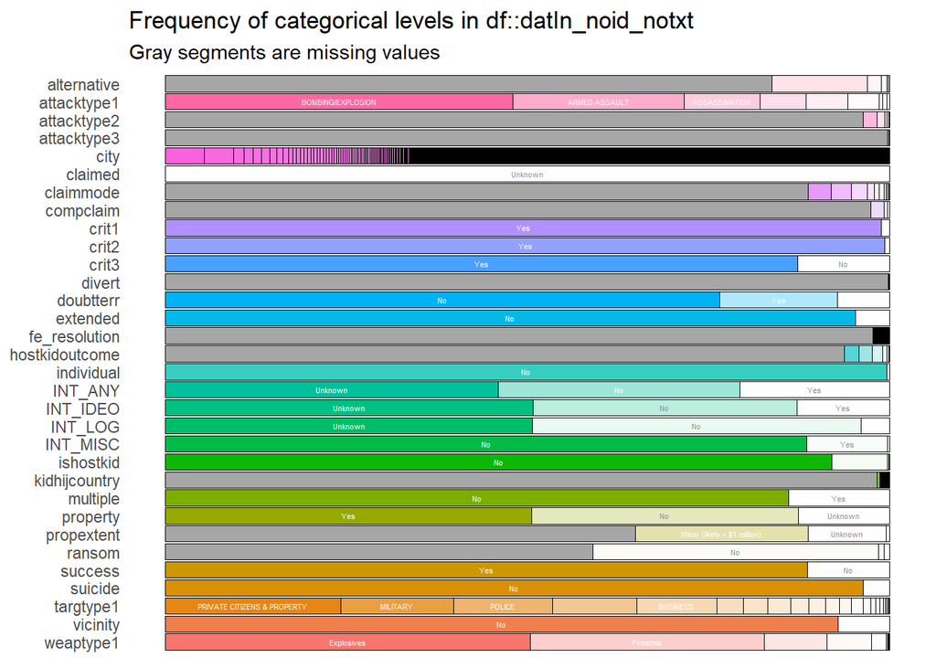

```r
#categorical plot
x <- inspect_cat(datIn_noid_notxt)
show_plot(x)
```

En el gráfico de frecuencias de las variables categóricas podemos ver variables con un gran número de categorías. Y variables cuyos niveles se podrían agrupar.

Las variables con un **gran número de categorías**, que no aportarían información relevante al modelo y los algortimos podrían perderse, por lo tanto, son **variables candidatas a eliminarse** del dataset:

- **‘city’**
- **‘fe_resolution’**
- **‘kidhijcountry’**: además esta variable tiene un gran número de valores perdidos.

**Variables** con muchos **niveles**, pero que se podrían **agrupar**:

- **targtype1**
- **weaptype1**

**Variable** con una **única categoría** y que, por lo tanto, se **elminaría** del dataset, ya que, no sería discriminante:

- **‘’claimed’’**

También podemos observar que existen **variables** con un **gran número de valores perdidos** (zona grisácea en el reparto de las categorías),que analizaré más adelante.

**A).- Variables con casos ‘Unknown’ Codificados**

A continuación , voy a analizar las distribucción de las variables categóricas que no serán eliminadas del dataset y además tienen codificadas en sus categorías el nivel ‘Unkonwn’. Con el **objetivo** de saber si **imputar** a **missing o no**, la categoría **‘Unknown’**.

```r
#Resumen valores faltantes, ceros y valores únicos
var_categoricas_unknown <- datIn_noid_notxt[c(19, 14, 52, 50, 49, 51, 38, 35, 22, 10, 30)]
df_status(var_categoricas_unknown )
```

```
##       variable q_zeros p_zeros q_na p_na q_inf p_inf   type unique
## 1  attacktype1       0       0    0 0.00     0     0 factor      9
## 2    doubtterr       0       0    0 0.00     0     0 factor      3
## 3      INT_ANY       0       0    0 0.00     0     0 factor      3
## 4     INT_IDEO       0       0    0 0.00     0     0 factor      3
## 5      INT_LOG       0       0    0 0.00     0     0 factor      3
## 6     INT_MISC       0       0    0 0.00     0     0 factor      3
## 7    ishostkid       0       0  178 0.09     0     0 factor      3
## 8     property       0       0    0 0.00     0     0 factor      3
## 9    targtype1       0       0    0 0.00     0     0 factor     22
## 10    vicinity       0       0    0 0.00     0     0 factor      3
## 11   weaptype1       0       0    0 0.00     0     0 factor     12
```

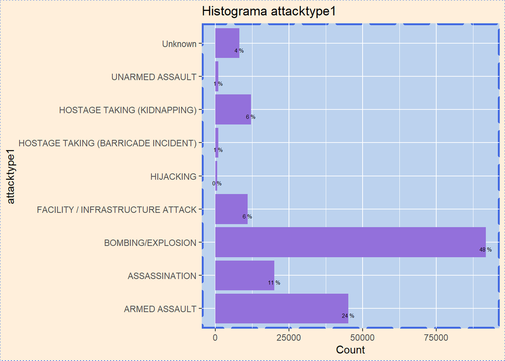

```r
#Gráfico de barras de attacktype1
ggplot(datIn_noid_notxt, aes(attacktype1, decreasing = TRUE), fill=Color) +
  geom_bar(position = "dodge", fill = "mediumpurple") +
  labs(title = "Histograma attacktype1",
       x =  "attacktype1",
       y = "Count") +
  coord_flip() + theme(plot.subtitle = element_text(vjust = 1),
    plot.caption = element_text(vjust = 1),
    panel.background = element_rect(fill = "lightsteelblue2",
        colour = "royalblue", size = 1.6,
        linetype = "longdash"), plot.background = element_rect(fill = "antiquewhite1",
        colour = "royalblue", linetype = "dotted")) +
  geom_text(stat = "count",
            aes(label = paste(round((..count..)/sum(..count..)*100), "%")),
            position = "stack",
            vjust = 2,
            size = 2,
            color = "black")
```

Observamos que para la variable **‘attacktype1’**, el porcentaje de valores ‘Unknown’ es bajo, un 4%. Paso **a missing** los casos **‘Unknown’**.

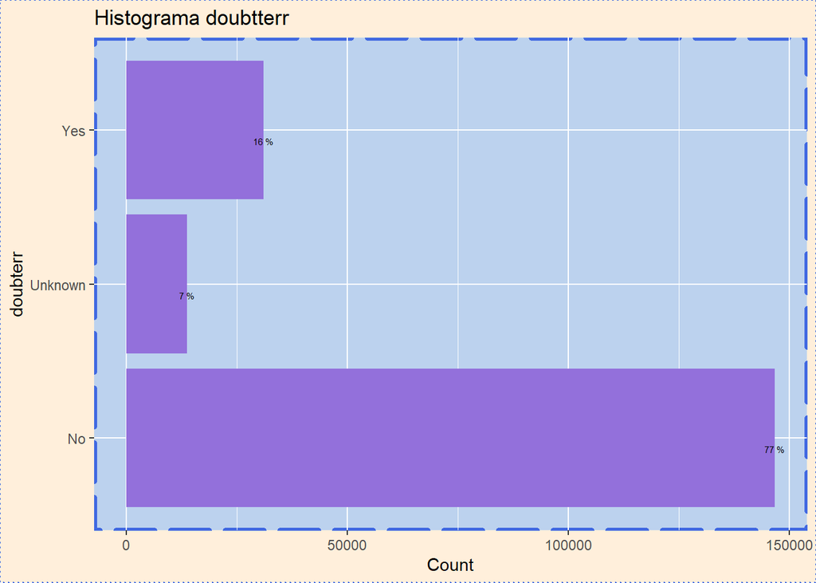

```r
#Gráfico de barras de doubterr
ggplot(datIn_noid_notxt, aes(doubtterr, decreasing = TRUE), fill=Color,size=0.01) +
  geom_bar(position = "dodge", fill = "mediumpurple") +
  labs(title = "Histograma doubtterr",
       x =  "doubterr",
       y = "Count") +
  coord_flip() + theme(plot.subtitle = element_text(vjust = 1),
    plot.caption = element_text(vjust = 1),
    panel.background = element_rect(fill = "lightsteelblue2",
        colour = "royalblue", size = 1.6,
        linetype = "longdash"), plot.background = element_rect(fill = "antiquewhite1",
        colour = "royalblue", linetype = "dotted")) +
  geom_text(stat = "count",
            aes(label = paste(round((..count..)/sum(..count..)*100), "%")),
            position = "stack",
            vjust = 2,
            size = 2,
            color = "black")
```

**‘Doubterr’** tiene un **7%** de valores **desconocidos**, por lo tanto, los imputo **a missing**.

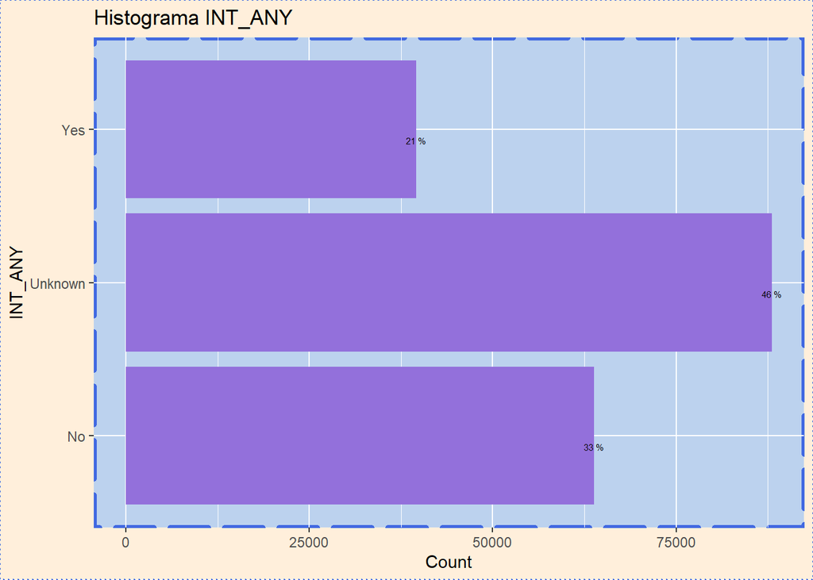

```r
#Gráfico de barras de INT_ANY
ggplot(datIn_noid_notxt, aes(INT_ANY, decreasing = TRUE), fill=Color,size=0.01) +
  geom_bar(position = "dodge", fill = "mediumpurple") +
  labs(title = "Histograma INT_ANY",
       x =  "INT_ANY",
       y = "Count") +
  coord_flip() + theme(plot.subtitle = element_text(vjust = 1),
    plot.caption = element_text(vjust = 1),
    panel.background = element_rect(fill = "lightsteelblue2",
        colour = "royalblue", size = 1.6,
        linetype = "longdash"), plot.background = element_rect(fill = "antiquewhite1",
        colour = "royalblue", linetype = "dotted")) +
  geom_text(stat = "count",
            aes(label = paste(round((..count..)/sum(..count..)*100), "%")),
            position = "stack",
            vjust = 2,
            size = 2,
            color = "black")
```

Podemos observar que **‘int_any’** tiene un **46%** de valores **‘Unknown’**, este porcentaje es bastante grande, lo que, consideraré en caso a ‘Unknown’ como **una categoría más**.

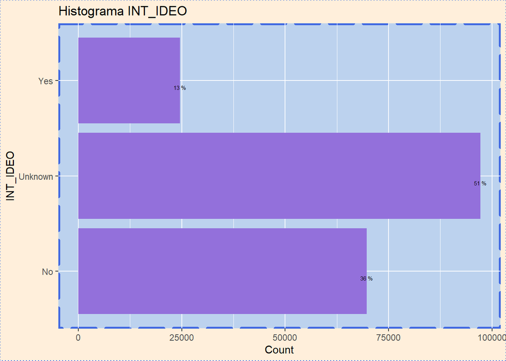

```r
#Gráfico de barras de INT_IDEO
ggplot(datIn_noid_notxt, aes(INT_IDEO, decreasing = TRUE), fill=Color,size=0.01) +
  geom_bar(position = "dodge", fill = "mediumpurple") +
  labs(title = "Histograma INT_IDEO",
       x =  "INT_IDEO",
       y = "Count") +
  coord_flip() + theme(plot.subtitle = element_text(vjust = 1),
    plot.caption = element_text(vjust = 1),
    panel.background = element_rect(fill = "lightsteelblue2",
        colour = "royalblue", size = 1.6,
        linetype = "longdash"), plot.background = element_rect(fill = "antiquewhite1",
        colour = "royalblue", linetype = "dotted")) +
  geom_text(stat = "count",
            aes(label = paste(round((..count..)/sum(..count..)*100), "%")),
            position = "stack",
            vjust = 2,
            size = 2,
            color = "black")
```

**‘Int_ideo’** tiene un **51%** de valores **‘Unknown’**, este porcentaje es bastante grande, lo que, consideraré en caso a ‘Unknown’ como **una categoría más**.

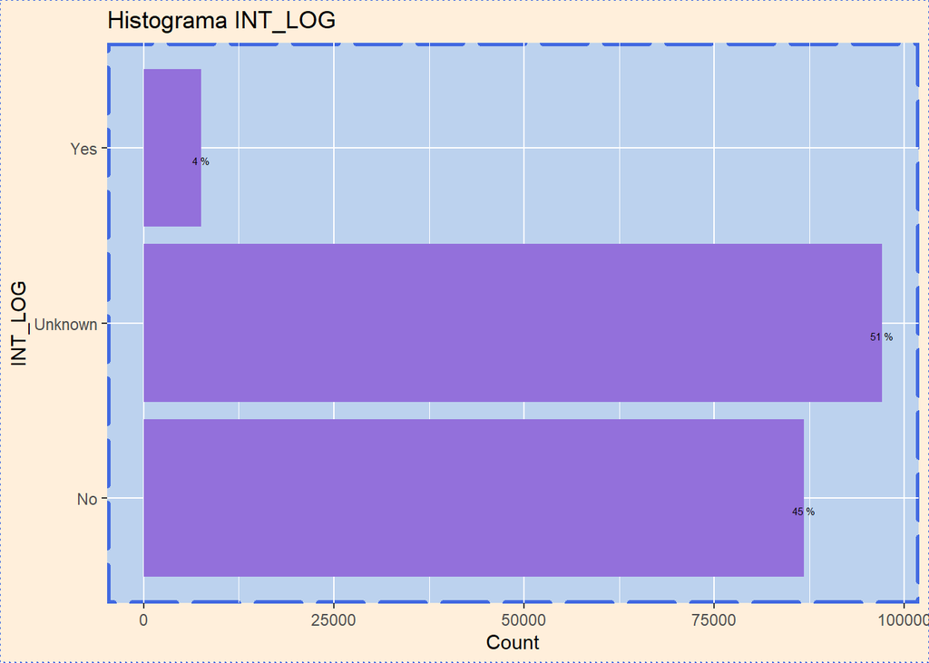

```r
#Gráfico de barras de INT_LOG
ggplot(datIn_noid_notxt, aes(INT_LOG, decreasing = TRUE), fill=Color,size=0.01) +
  geom_bar(position = "dodge", fill = "mediumpurple") +
  labs(title = "Histograma INT_LOG",
       x =  "INT_LOG",
       y = "Count") +
  coord_flip() + theme(plot.subtitle = element_text(vjust = 1),
    plot.caption = element_text(vjust = 1),
    panel.background = element_rect(fill = "lightsteelblue2",
        colour = "royalblue", size = 1.6,
        linetype = "longdash"), plot.background = element_rect(fill = "antiquewhite1",
        colour = "royalblue", linetype = "dotted")) +
  geom_text(stat = "count",
            aes(label = paste(round((..count..)/sum(..count..)*100), "%")),
            position = "stack",
            vjust = 2,
            size = 2,
            color = "black")
```

Al igual que en el caso anterior, **‘Int_log’** tiene un **51%** de valores **‘Unknown’**, este porcentaje es bastante grande, lo que, consideraré en caso a ‘Unknown’ como **una categoría más**.

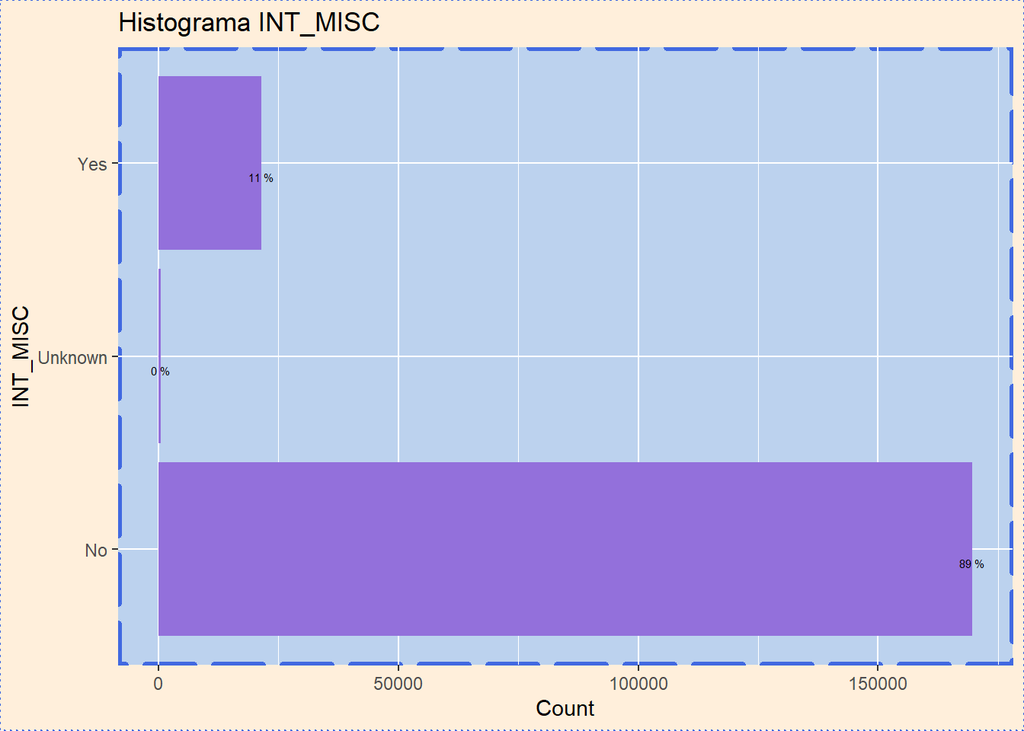

```r
#Gráfico de barras de INT_MISC
ggplot(datIn_noid_notxt, aes(INT_MISC, decreasing = TRUE), fill=Color,size=0.01) +
  geom_bar(position = "dodge", fill = "mediumpurple") +
  labs(title = "Histograma INT_MISC",
       x =  "INT_MISC",
       y = "Count") +
  coord_flip() + theme(plot.subtitle = element_text(vjust = 1),
    plot.caption = element_text(vjust = 1),
    panel.background = element_rect(fill = "lightsteelblue2",
        colour = "royalblue", size = 1.6,
        linetype = "longdash"), plot.background = element_rect(fill = "antiquewhite1",
        colour = "royalblue", linetype = "dotted")) +
  geom_text(stat = "count",
            aes(label = paste(round((..count..)/sum(..count..)*100), "%")),
            position = "stack",
            vjust = 2,
            size = 2,
            color = "black")
```

**‘Int_misc’** tiene una **incidencia muy baja** de casos **‘Unknown’**, por lo tanto, imputaré estos casos **a missing**.

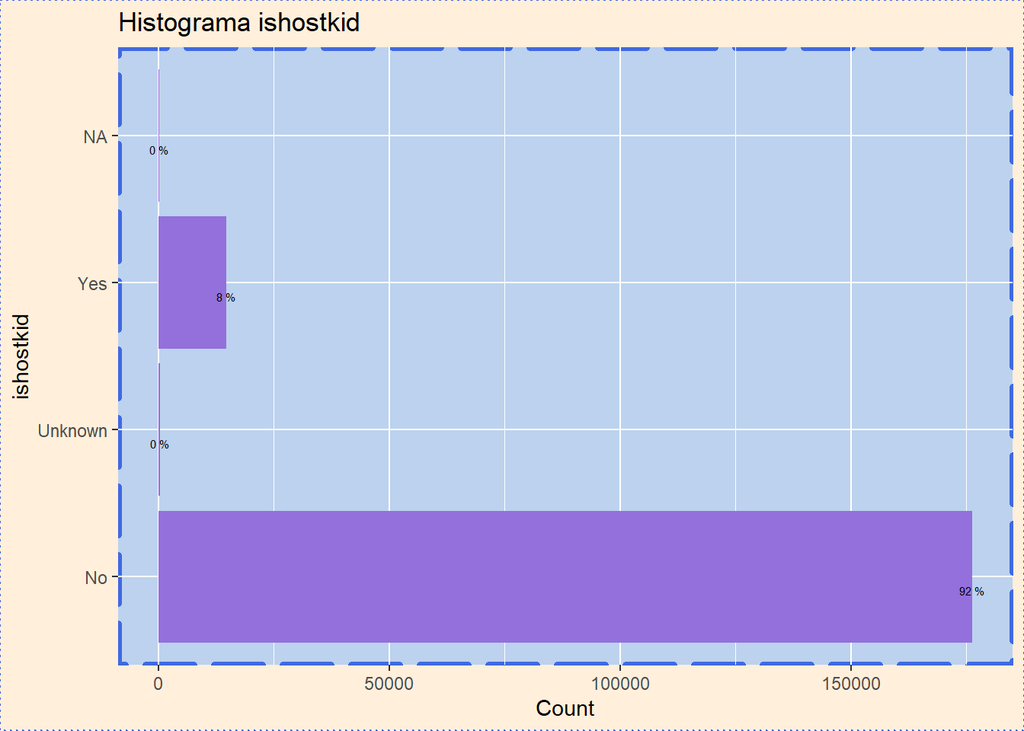

```r
#Gráfico de barras de ishostkid
ggplot(datIn_noid_notxt, aes(ishostkid, decreasing = TRUE), fill=Color,size=0.01) +
  geom_bar(position = "dodge", fill = "mediumpurple") +
  labs(title = "Histograma ishostkid",
       x =  "ishostkid",
       y = "Count") +
  coord_flip() + theme(plot.subtitle = element_text(vjust = 1),
    plot.caption = element_text(vjust = 1),
    panel.background = element_rect(fill = "lightsteelblue2",
        colour = "royalblue", size = 1.6,
        linetype = "longdash"), plot.background = element_rect(fill = "antiquewhite1",
        colour = "royalblue", linetype = "dotted")) +
  geom_text(stat = "count",
            aes(label = paste(round((..count..)/sum(..count..)*100), "%")),
            position = "stack",
            vjust = 2,
            size = 2,
            color = "black")
```

**‘Ihostkid’** tiene un **porcentaje muy bajo** de casos **‘Unknown’**, como vimos anteriormente, los casos de missing de la variable, también es muy bajo, por lo tanto, imputaré las observaciones de esta variable **a missing**.

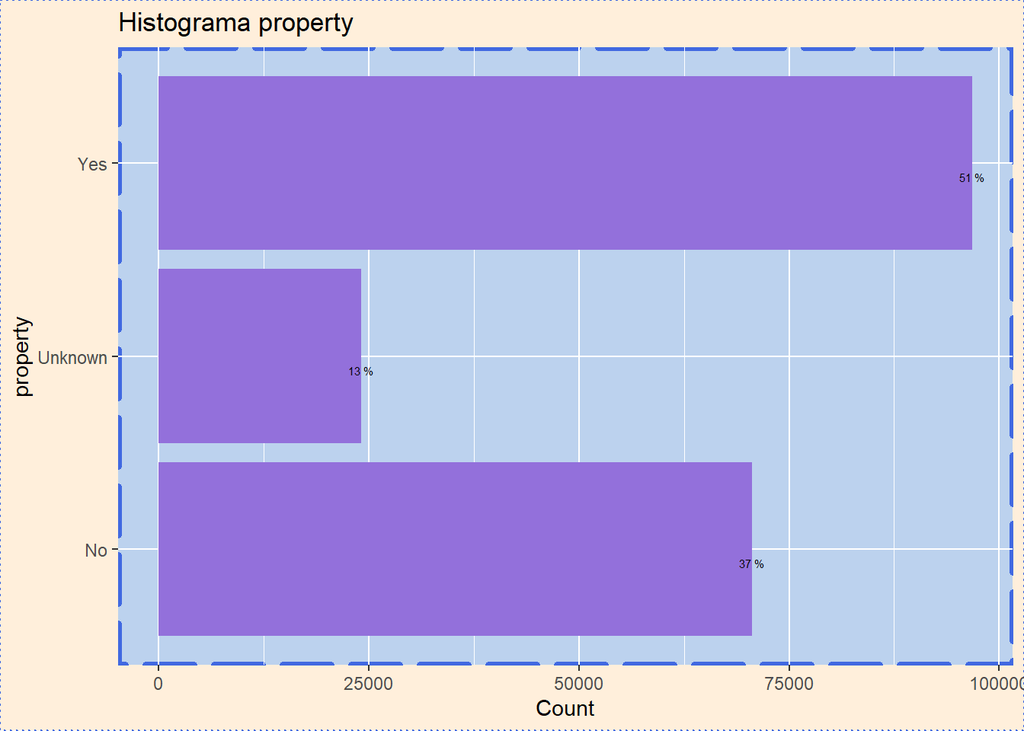

```r
#Gráfico de barras de property
ggplot(datIn_noid_notxt, aes(property, decreasing = TRUE), fill=Color,size=0.01) +
  geom_bar(position = "dodge", fill = "mediumpurple") +
  labs(title = "Histograma property",
       x =  "property",
       y = "Count") +
  coord_flip() + theme(plot.subtitle = element_text(vjust = 1),
    plot.caption = element_text(vjust = 1),
    panel.background = element_rect(fill = "lightsteelblue2",
        colour = "royalblue", size = 1.6,
        linetype = "longdash"), plot.background = element_rect(fill = "antiquewhite1",
        colour = "royalblue", linetype = "dotted")) +
  geom_text(stat = "count",
            aes(label = paste(round((..count..)/sum(..count..)*100), "%")),
            position = "stack",
            vjust = 2,
            size = 2,
            color = "black")
```

**‘Property’** tiene una incidencia de **‘Unkonwn’** del **13%**, está por debajo del 25%, por lo que, imputaré los casos **a missing**.

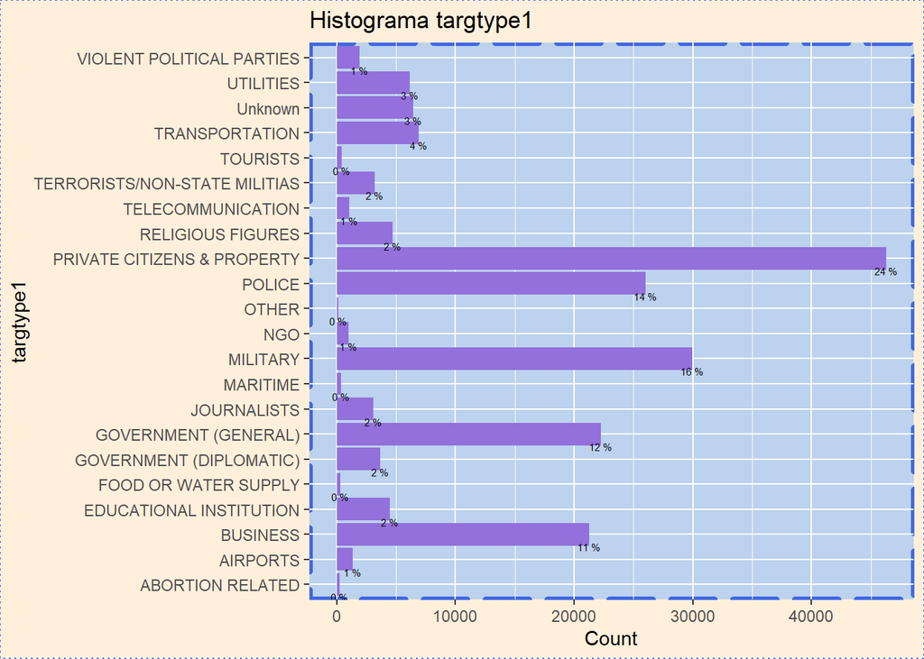

```r
#Gráfico de barras de targtype1
ggplot(datIn_noid_notxt, aes(targtype1, decreasing = TRUE), fill=Color,size=0.01) +
  geom_bar(position = "dodge", fill = "mediumpurple") +
  labs(title = "Histograma targtype1",
       x =  "targtype1",
       y = "Count") +
  coord_flip() + theme(plot.subtitle = element_text(vjust = 1),
    plot.caption = element_text(vjust = 1),
    panel.background = element_rect(fill = "lightsteelblue2",
        colour = "royalblue", size = 1.6,
        linetype = "longdash"), plot.background = element_rect(fill = "antiquewhite1",
        colour = "royalblue", linetype = "dotted")) +
  geom_text(stat = "count",
            aes(label = paste(round((..count..)/sum(..count..)*100), "%")),
            position = "stack",
            vjust = 2,
            size = 2,
            color = "black")
```

**‘Targtype1’** tiene un **3%** de casos **‘Unknown’**, por lo que, imputaré los casos **a missing**.

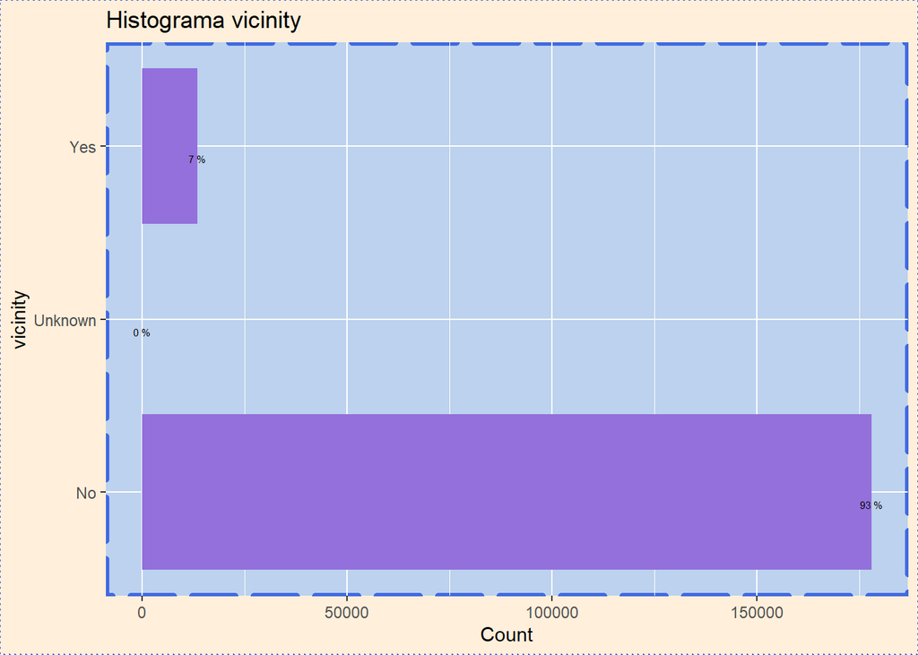

```r
#Gráfico de barras de vicinity
ggplot(datIn_noid_notxt, aes(vicinity, decreasing = TRUE), fill=Color,size=0.01) +
  geom_bar(position = "dodge", fill = "mediumpurple") +
  labs(title = "Histograma vicinity",
       x =  "vicinity",
       y = "Count") +
  coord_flip() + theme(plot.subtitle = element_text(vjust = 1),
    plot.caption = element_text(vjust = 1),
    panel.background = element_rect(fill = "lightsteelblue2",
        colour = "royalblue", size = 1.6,
        linetype = "longdash"), plot.background = element_rect(fill = "antiquewhite1",
        colour = "royalblue", linetype = "dotted")) +
  geom_text(stat = "count",
            aes(label = paste(round((..count..)/sum(..count..)*100), "%")),
            position = "stack",
            vjust = 2,
            size = 2,
            color = "black")
```

**‘Vicinity’** tiene un **porcentaje** de **‘Unknowns’ muy bajo**, por debajo del 1%, por lo que, los casos los imputaré **a missing**.

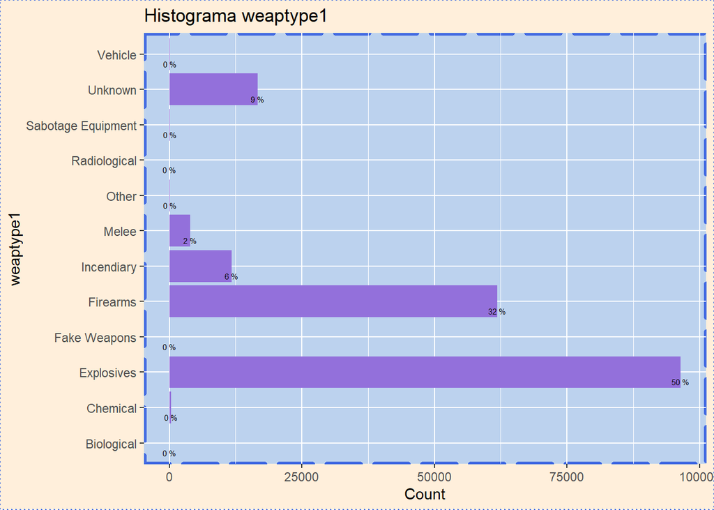

```r
#Gráfico de barras de weaptype1
ggplot(datIn_noid_notxt, aes(weaptype1, decreasing = TRUE), fill=Color,size=0.01) +
  geom_bar(position = "dodge", fill = "mediumpurple") +
  labs(title = "Histograma weaptype1",
       x =  "weaptype1",
       y = "Count") +
  coord_flip() + theme(plot.subtitle = element_text(vjust = 1),
    plot.caption = element_text(vjust = 1),
    panel.background = element_rect(fill = "lightsteelblue2",
        colour = "royalblue", size = 1.6,
        linetype = "longdash"), plot.background = element_rect(fill = "antiquewhite1",
        colour = "royalblue", linetype = "dotted")) +
  geom_text(stat = "count",
            aes(label = paste(round((..count..)/sum(..count..)*100), "%")),
            position = "stack",
            vjust = 2,
            size = 2,
            color = "black")
```

### 1.2.2 Nivel de desbalanceo de las variables categóricas

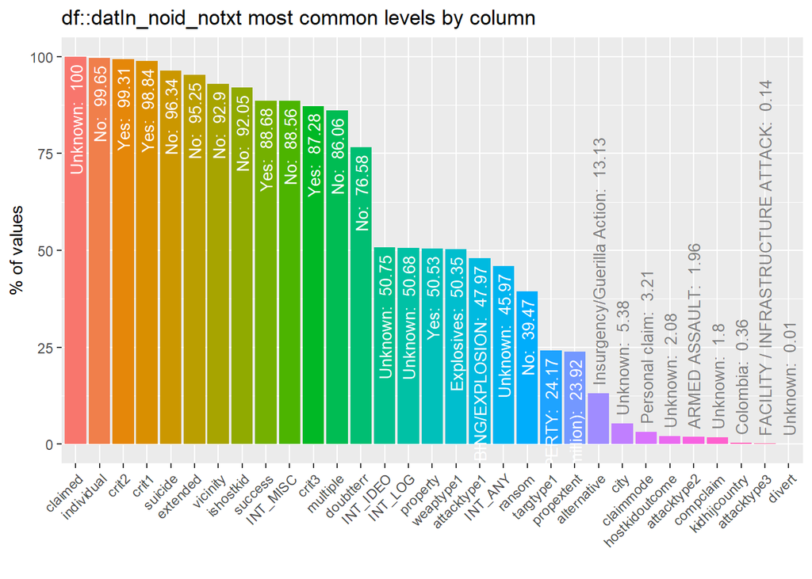

```r
#feature imbalance bar plot
x <- inspect_imb(datIn_noid_notxt)
show_plot(x)
```

Hay un cierto número de **variables** que están **desbalanceadas**, unas de sus categorías está por encima de 85%, **incluida** la **variable objetivo** ‘success’.

Por lo tanto, a la hora de modelizar, **parametrizaré** los **algoritmos** que voy a utilizar **para que favorezcan** a las **clases minoritarias**.

Además, en vez, de utilizar técnicas de sub/sobre muestreo, parametrizaremos estos algoritmos, para que nos **optimicen** no sólo la métrica de ‘Accuacy’ si no también **la métrica de ‘Recall’**.

### 1.2.3 Tamaño de memoria

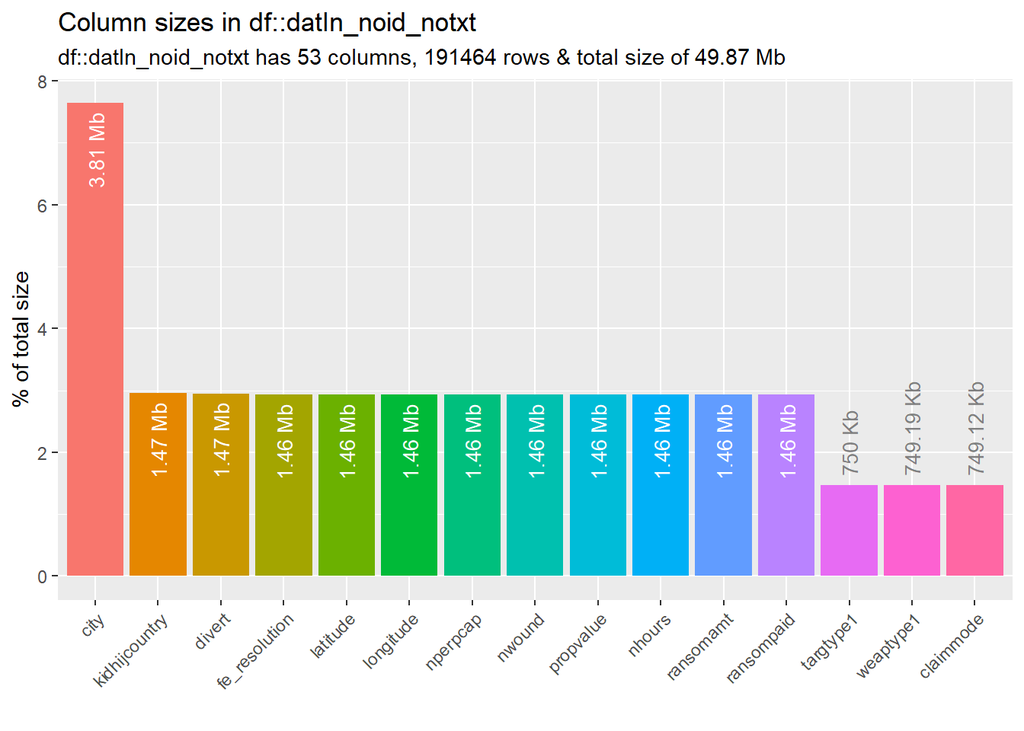

```r
x <- inspect_mem(datIn_noid_notxt)
#Para que muestre sólo las 15 primeras
x_bigger <- x[1:15,]
show_plot(x_bigger)
```

En el gráfico muestro las 15 variables que ocupan mayor espacio de memoria.

Vemos como **‘city’** es la variable que **mayor espacio ocupa** con diferencia. Esta variable será eliminada del dataset, por tener un gran número de categorías, lo cúal **no afectará** de manera significativa a la memoria.

### 1.2.4 Número de valores perdidos

**Número de valores missinng por variables**

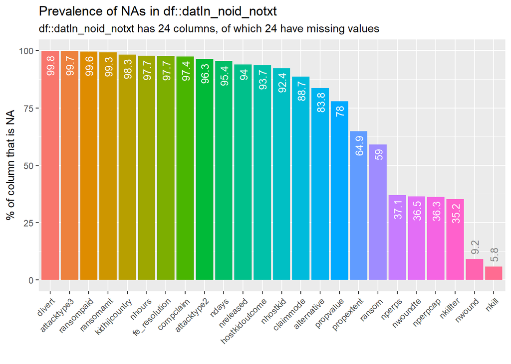

```r
x <- inspect_na(datIn_noid_notxt)
#Muestro sólo las mayor porcentaje
x_mayor <- filter(x, pcnt > 5.0)
show_plot(x_mayor)
```

Muestro las variables que presentan un número de valores perdidos superior al 5%.

Podemos ver que existe un **gran número de variables** con **valores perdidos**. **Eliminaré** del dataset las variables que presenten un porcentaje **mayor del 50% de datos missing**.

Estas variables son:

- **ransom**
- **‘propextent’**
- **‘propvalue’**
- **‘alternative’**
- **‘claimmode’**
- **‘nhostkid’**
- **‘hostkidoutcome’**
- **‘nreleased’**
- **‘ndays’**
- **‘attacktype2’**
- **‘compclaim’**
- **‘fe_resolution’**
- **‘nhours’**
- **‘kidhijcountry’**
- **‘ransomamt’**
- **‘ransompaid’**
- **‘attacktype3’**
- **‘divert’**

Los **missing** del **resto de variables** los **imputaré** por el **Algoritmo MissRanger**

**- Número de valores missing por observación**

A continuación, miramos si existe alguna observación con más del 50% de valores perdidos.

```r
#Creo la variable de prop_missings por observación
datIn_noid_notxt$prop_missings <- apply(is.na(datIn_noid_notxt), 1, mean)
summary(datIn_noid_notxt$prop_missings)
```

```
##    Min. 1st Qu.  Median    Mean 3rd Qu.    Max.
## 0.09434 0.30189 0.33962 0.33995 0.37736 0.49057
```

Vemos que **existen** observaciones con un **porcentaje de missing del 49%**. Por lo tanto, **no eliminaré** ninguna **observación**.

### 1.2.5 Inspeción de las variables numéricas

**- Tabla de valores faltantes, ceros y valores únicos**

```r
#install.packages("funModeling")
#library(funModeling)
#Variables numéricas
var_numericas <- datIn_noid_notxt[c(1,2,3,5,6,8,9,23,25,26,31,32,33,34,37,39,40,41,45,46,48)]
df_status(var_numericas)
```

```
##      variable q_zeros p_zeros   q_na  p_na q_inf p_inf    type unique
## 1       iyear       0    0.00      0  0.00     0     0 integer     48
## 2      imonth      20    0.01      0  0.00     0     0 integer     13
## 3        iday     891    0.47      0  0.00     0     0 integer     32
## 4     country       0    0.00      0  0.00     0     0 integer    205
## 5      region       0    0.00      0  0.00     0     0 integer     12
## 6    latitude       0    0.00   4580  2.39     0     0 numeric  54221
## 7   longitude       0    0.00   4581  2.39     0     0 numeric  54080
## 8     natlty1       0    0.00   1722  0.90     0     0 integer    215
## 9      nperps     139    0.07  71109 37.14     0     0 integer    114
## 10   nperpcap  115425   60.29  69483 36.29     0     0 numeric     51
## 11      nkill   92328   48.22  11029  5.76     0     0 integer    207
## 12   nkillter  109577   57.23  67434 35.22     0     0 integer     99
## 13     nwound  107978   56.40  17559  9.17     0     0 numeric    240
## 14   nwoundte  118734   62.01  69870 36.49     0     0 integer     48
## 15  propvalue     195    0.10 149268 77.96     0     0 numeric    682
## 16   nhostkid       6    0.00 176838 92.36     0     0 integer    210
## 17     nhours    1293    0.68 187083 97.71     0     0 numeric     35
## 18      ndays     226    0.12 182603 95.37     0     0 integer    346
## 19  ransomamt     340    0.18 190048 99.26     0     0 numeric    466
## 20 ransompaid     255    0.13 190626 99.56     0     0 numeric    174
## 21  nreleased    2560    1.34 180010 94.02     0     0 integer    160
```

A continuación, muestro un **resumen gráfico** de aquellas **variables numéricas** que **no** serán **eliminadas** del dataset, por tener un porcentaje de valores perdidos inferior al 50%.

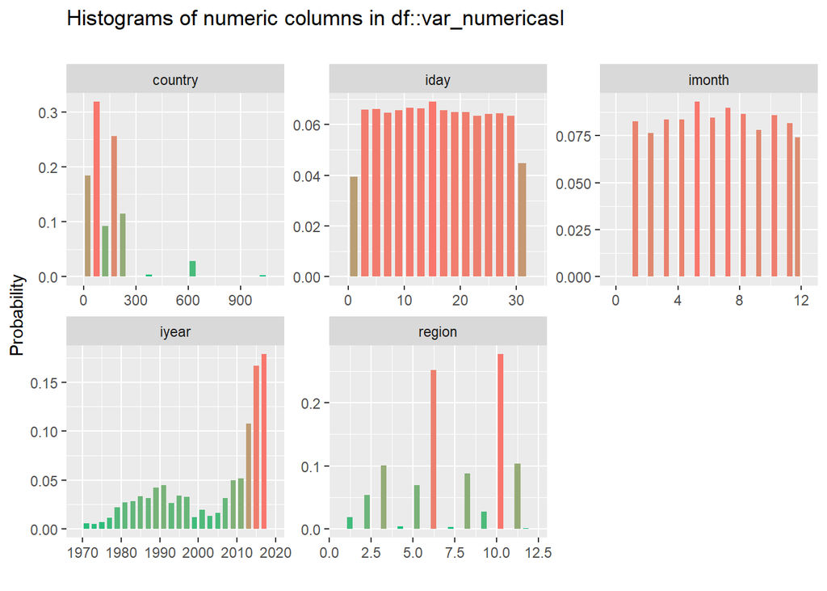

```r
#Histogramas para las variables numéricas
#Muestro los gráficos en grupos de 5 para que se vean bien
var_numericasI <- datIn_noid_notxt[c(1,2,3,5,6)]
x <- inspect_num(var_numericasI)
show_plot(x)
```

Podemos **observar** tanto en los **gráficos** cómo en las **tablas** que:

- **‘Country’**: tiene una **baja incidencia** de **‘Outliers’**, por lo que, imputaré estos valores por regresión (Algortimo de missRanger).
- **‘iday’ e ‘imonth’**: ambas variables tienen un **pequeño porcentaje de ceros**, los cuales cambiaré a NA, para posteriormente **imputarlos** mediante el **algoritmo ‘missRanger’**.

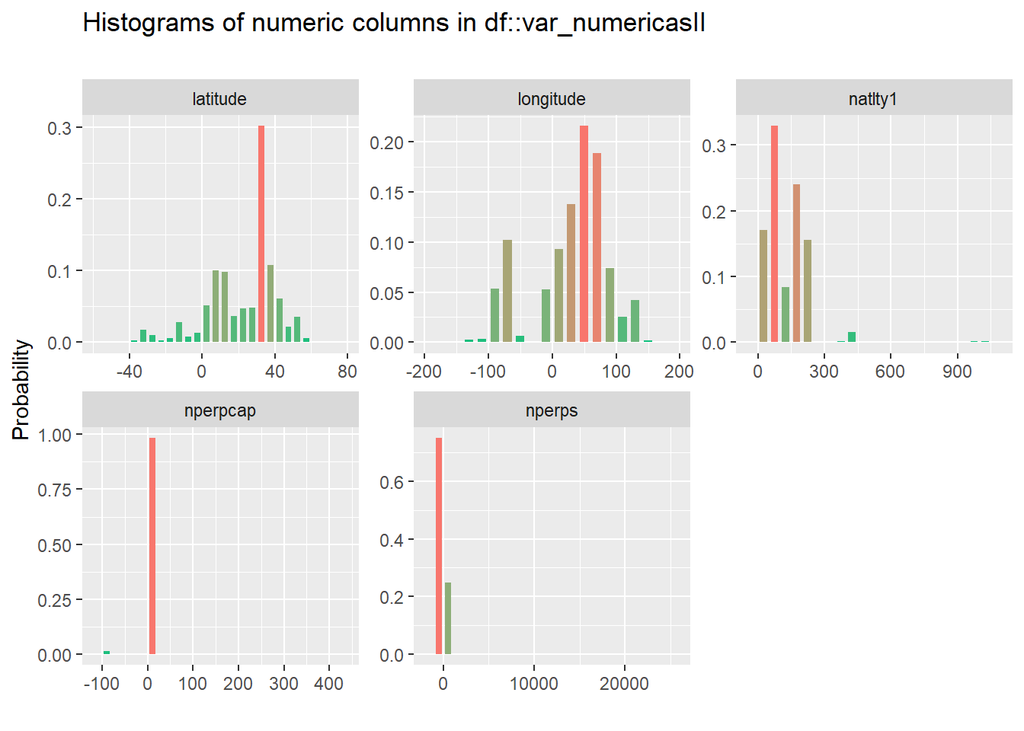

```r
#Histogramas para las variables numéricas
var_numericasII <- datIn_noid_notxt[c(8,9,23,25,26)]
x <- inspect_num(var_numericasII)
show_plot(x)
```

- **‘latitude’ y ‘longitude’**: tienen ciertos **valores** como **‘NA’**, cuyos porcentajes son menores al 50%, los **imputaré** con el algortimo **‘Missranger’**.
- **‘nattly1’**: tiene un **porcentaje pequeño**, tanto de **valores perdidos**, como de **outliers**, por lo que estos valores, serán imputados por regresión.
- **‘nperps’**: contiene el **número de participantes** en un atentado. Este número **debe ser mayor que cero**. Si observamos la distribución de esta variable, podemos observar, que la variable tiene un **gran número** de **valores menores o iguales que cero** (un **47%**). Si además, **añadimos** a la imputación, los **valores missing** que ya tiene de por sí la variable (un **37%**), sería **imputar** un **total** del **84%** de la información de esta variable, lo cual **no es adecuado**. Por lo que, que **tramificaré** la variable en la parte de Feature Engineering. Los **valores** que son **menores que cero**, los imputaré el valor -99999 (Codificado como **‘Unknwon’**). De esta manera, **no perderemos la información**. Y además, al considerar la variable como categórica, tenemos la ventaja de poder **captar relaciones no lineales** con la **variable objetivo**.
- **‘nperpcap’**: Considera el **número** de **terroristas detenidos**. Si observamos el gráfico, podemos ver que tiene una proporción de **ceros** considerable (**60%**), pero **posible**. También podemos ver que existen **valores menores que cero** (**1%**), y un porcentaje de **Missing del 36%**. Por su distribución totalmente asímetrica a la izquierda, es posible que como numérica no aporte variabilidad la modelo, por lo tanto, la voy a recategorizar. Tendré en cuenta **dos escenarios**, **uno** incluyendo la **variable numérica** en el dataset, y **otro**, inlcuyendo sólo la **variable recategorizada**. De esta forma, analizaré cuál de las dos variables aportan mayor información al modelo.
  1. Para el **caso** de la **variable numérica**, **imputaré** por el **algoritmo missRanger** los valores **missing** y los **valores negativos**.
  2. Para la **variable recodificada**, al igual que para la variable numérica, los **missing por regresión**. Y los **valores menores que cero 0 a** -99999(**‘Unknwon’**)

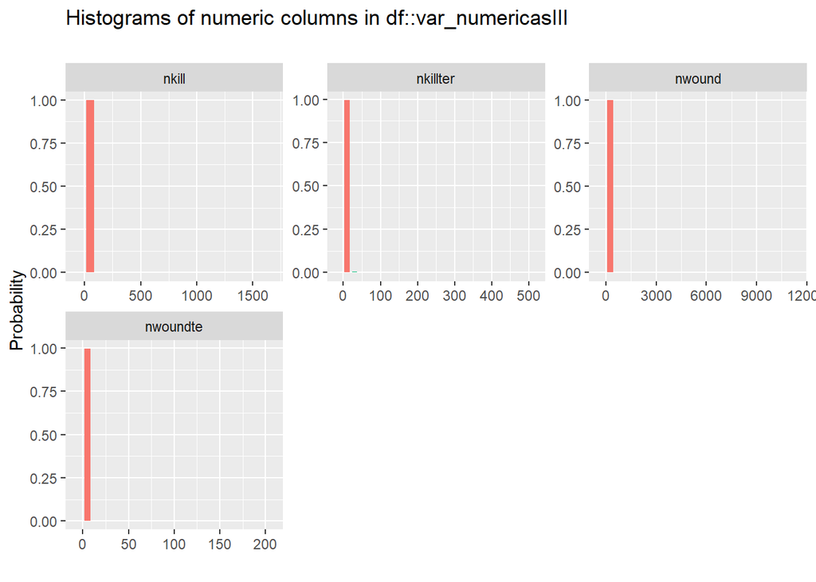

```r
#Histogramas para las variables numéricas
var_numericasIII <- datIn_noid_notxt[c(31,32,33,34)]
x <- inspect_num(var_numericasIII)
show_plot(x)
```

- **‘nkill’**: esta variable considera el **número de muertos en un atentado**. Podemos ver tiene un **gran número de ceros** (**48%**), valores posibles de la variable. Además, de un **5% de valores perdidos**. En esta ocasión **no hay valores negativos**. Siguiendo el **mismo patrón** de análisis **anterior**, **tramificaré** la **variable** y **analizaré alternativamente**, con la variable numérica y con la variable recodificada, el **ajuste del modelo** en todos los algoritmos que utilice.
  1. Para el **caso** de la **variable numérica**, **imputaré** por el **algoritmo missRanger** los valores **missing**.
  2. Para la **variable recodificada**, al igual que para la variable numérica, los **missing por regresión**.
- **‘nkillter’**: recoge el **número de atacantes muertos en el atentado**. Al igual que en la variable anterior, tiene un **gran número de ceros** (57%). **No** tiene **valores negativos**. Por lo que, al igual que con la variable anterior, **tramificaré** esta variable y **analizaré la posibilidad** de incluir en el modelo la **variable numérica ó la variable recategorizada**, será aquella que aporte **mayor variabilidad** al modelo.
  1. Para el **caso** de la **variable numérica**, **imputaré** por el **algoritmo missRanger** los valores **missing**.
  2. Para la **variable recodificada**, al igual que para la variable numérica, los **missing por regresión**.
- **‘nwound’**: mide el **número de heridos total en el atentado**. Al igual que en las variables anteriores, tiene un **gran número de ceros** (56%), **valores permitidos** en esta variable. **No** tiene **valores negativos**. Además, tiene un **9%** de valores **perdidos**. Por lo tanto, al **igual** que en el **caso anterior**, **tramificaré** la variable y **estudiaré** la posibilidad de **incluir en el dataset del modelo**, la **variable numérica ó tramificada**.
  1. Para el **caso** de la **variable numérica**, **imputaré** por el **algoritmo missRanger** los valores **missing**.
  2. Para la **variable recodificada**, al igual que para la variable numérica, los **missing por regresión**.
- **‘nwoundte’**: recoge el **número de terroristas heridos en el atentado**. Tiene un **62% de ceros**, **valores permitidos** en esta variable. **No** tiene **valores negativos**. Y tiene un **36% de valores perdidos**. Por lo que, al igual que en casos anteriores, **tramificaré la variable** y **analizaré** la posibilidad de **introducir** en el **modelo final** la **variable numérica** **ó** la **tramificada**, aquella que **optimice** la bondad del **ajuste**.
  1. Para el **caso** de la **variable numérica**, **imputaré** por el **algoritmo missRanger** los valores **missing**.
  2. Para la **variable recodificada**, al igual que para la variable numérica, los **missing por regresión**.

### 1.2.6 Outliers

```r
source("./Funciones_R.R") #Cargo el archivo de funciones necesarias para este análisis
#Cargo la liberia necesaria
library(psych)
#Muestro la incidencia de outliers de las variables numéricas que no serán elimindas
var_numericas_entran <-datIn_noid_notxt[c(1,2,3,5,6,8,9,23,25,26,31,32,33,34)]
out <- sapply(Filter(is.numeric, var_numericas_entran),function(x) atipicosAmissing(x)[[2]])/nrow(datIn_noid_notxt)
out
```

```
##       iyear      imonth        iday     country      region    latitude
## 0.000000000 0.000000000 0.000000000 0.002527890 0.000000000 0.000000000
##   longitude     natlty1      nperps    nperpcap       nkill    nkillter
## 0.000000000 0.003044959 0.157100029 0.034241424 0.056538044 0.075486776
##      nwound    nwoundte
## 0.069355075 0.014937534
```

Si nos centramos en las variables numéricas que entraran en el dataset a analizar, podemos observar que, las **variables** que **tienen** una **gran cantidad de valores cero**, son las variables que **tienen** una **incidencia mayor** de **outliers**.

Estas variables son:

- **‘nperps’**
- **‘nkillter’**
- **‘nwound’**
- **‘nkill’**
- **‘nperpcap’**

Por lo tanto, para estas variables en concreto, **no** los **eliminaré**, los dejo tal cual, **ya que** los pocos **valores** que **no son 0 ó -99** (en el caso de ‘nperpcap’ y ‘nperps’), los **considero relevantes**.

El resto de variables como, **natlty1 y country**, tienen una **incidencia** de valores atípicos, mucho **más pequeña**, por lo tanto, **estos** **outliers** serán **imputados** por el algortimo **missRanger**, dónde los valores se imputarán en función del resto de las variables.

### 1.2.7 Análisis de las correlaciones entre las variables numéricas

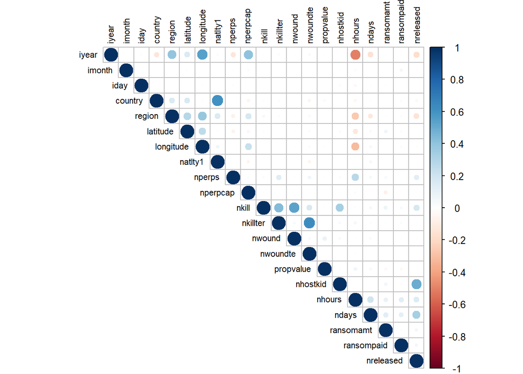

```r
#Variables numéricas
var_numericas <- datIn_noid_notxt[c(1,2,3,5,6,8,9,23,25,26,31,32,33,34,37,39,40,41,45,46,48)]
#Correlaciones entre las variables numéricas
corrplot(cor(var_numericas, use="pairwise",
             method="pearson"), method = "circle",type = "upper",tl.col = "black",tl.cex = 0.7)
```

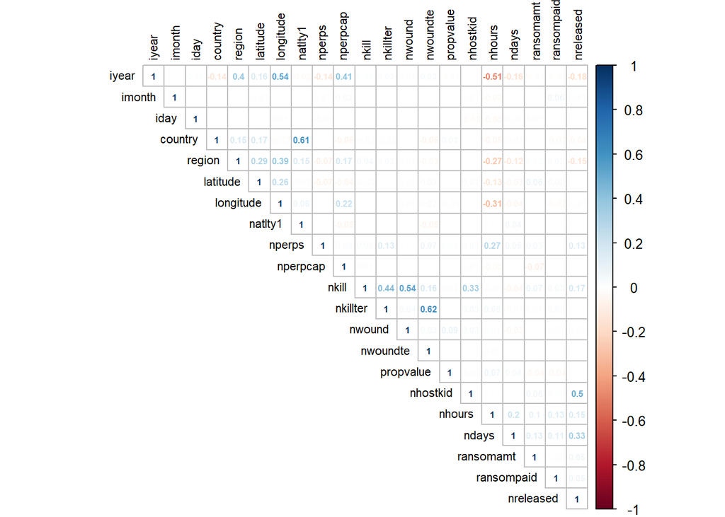

```r
corrplot(cor(var_numericas, use="pairwise",
             method="pearson"), method = "number",type = "upper",tl.col = "black",number.cex = 0.5, tl.cex = 0.7)
```

Las variables numéricas con una **mayor correlación** son el código del pais (**‘country’**) **con** la nacionalidad de la victima/objetivo (**’natlty1’**), **y** el número de atancantes muertos (**‘nkillter’**) **con** el número de terrostistas heridos (**‘nwoundte’**). Estas dos correlaciones se sitúan **alrededor del 60%**. **No** es una correlación muy **alta**, por lo tanto, las variables numéricas **no** deberían dar problemas de **multicolinealidad**.

### 1.2.8 Conclusiones del EDA

Con el análisis descriptivo de los datos, he llegado a las siguientes conclusiones:

1.-**Variables** que se **eliminan**, bien por tener un gran número de categorías, una sóla categoría o por tener un gran porcentaje de valores perdidos:

- **‘city’**
- **‘fe_resoution’**
- **‘kidhijicountry’**
- **‘claimed’**
- **‘ransom’**
- **‘propextent’**
- **‘propvalue’**
- **‘alternative’**
- **‘claimmode’**
- **‘nhostkid’**
- **‘hostkidoutcome’**
- **‘nreleased’**
- **‘ndays’**
- **‘attacktype2’**
- **‘compclaim’**
- **‘nhours’**
- **‘ransomamt’**
- **‘ransompaid’**
- **‘attacktype3’**
- **‘divert’**

2.- **Variables cualitativas** con casos **‘Unknown’** Codificados.

Hemos visto que hay **variables** con **categorías ‘Unkonwn’**. Por lo que, **si** los **casos** de estas variables son importantes (por **encima del 25%**), los **consideraré como una categoría más**, por el contrario, **si** este porcentaje está por **debajo** del **25%**, imputaré estos casos **a missing**.

Los casos **‘Unknown’** de las variables que irán imputados **a missing** son:

- **‘attacktype1’**
- **‘doubterr’**
- **‘INT_MISC’**
- **‘ishostkid’**
- **‘property’**
- **‘targtype1’**
- **‘vicinity’**
- **‘weaptype1’**

**Variables** con **‘Unknown’ como una categoría** más:

- **‘INT_ANY’**
- **‘INT_IDEO’**
- **‘INT_LOG’**

3.- Tratamiento de **Outliers**

- **‘country’ y ’nattly1**: ambas variables tienen una **baja incidencia** de Outliers, por lo tanto, esos valores los pasaré **a missing** y posteriormente los imputaré por regresión con el algoritmo missRanger.
- El resto de **variables** **con** incidencia de outliers, es debido a la **gran cantidad de valores cero o valores negativos** que tienen, por lo tanto, **no** los **eliminaré**, **ni** los **imputaré** ya que los pocos **valores** que no son cero ó negativos los considero **relevantes**.

5.- **Valores perdidos**.

Los valores perdidos de las variables serán **imputados** por el algoritmo **missRanger**.

6.- **Recategorización** de variables numéricas.

**Variables** que, por sus distribucciones totalmente asimétricas a la izquierda, **como númericas** tendrían **poco que aportar**, las voy a **recategorizar** para **no perder información** y poder captar así relaciones no lineales con la variable objetivo.

Excepto **para** la variable **‘nperps’**, que **sólo** mantendré en el dataset, la variable **recategorizada**, para el **resto** de las variables especificadas abajo, tendré en cuenta **dos situaciones**, **una**, **incluyendo** en el conjunto de datos sólo la variable **numérica**, y **otra**, incluyendo sólo la variable **recategorizada**. Analizando así la bondad del ajuste en cada una de las situaciones.

Estas variables son:

- **‘nperps’**: **sólo** tendré en cuenta la **variable recategorizada**. Esta variable como vimos, tiene un gran número de **valores menores o iguales a cero**, que imputaré al valor **-99999** (‘Unknown’).
- **‘nperpcap’**: en este caso, al tener **valores negativos** los imputaré, en el caso de la variable numérica a missing, y en el caso de la variable recategorizada a -99999 (‘Unknown’).
- **‘nkill’**, **‘nkillter’**, **‘nwound’** y **‘nwoundte’**: **no** tienen valores **negativos**, por lo que los **missing** tanto de la variable **numérica**, como de la variable **recategorizada** se imputarán por **missRanger**.

7.-**Unión de niveles** en variables categóricas.

Variables que tienen **niveles** con un porcentaje menor del 5% de los casos, es decir, niveles **pocos representativos**, los agruparé:

- **‘targtype1’**
- **‘weaptype1’**

8.-**Creación** de **nuevas** variables

Incluiré en el dataset tres nuevas variables, que creo que pueden ser interesantes:

- **‘distancia’**: medirá la distancia entre la longitud y la latitud.
- **‘trimestre’**: agrupará la información por trimestres.
- **‘quincena’**: computará los dias de los meses por quincenas.

**Al igual** que con las variables recategorizadas, mencionadas en el **punto anterior**, estas tres variables las **analizaré** en **dos escenarios diferentes**. **Uno**, creando un dataset dónde se incluyan las **variables numéricas originales**, y **otro**, incluyendo en el conjunto de datos las **nuevas variables** categorizadas.

9.-Existencia de **variables desbalanceadas**.

Debido a la existencia de variables desbalanceadas, habrá que **parametrizar** los **algoritmos** para que **favorezacan** a las **clases minoritarias**. A su vez, parametrizaré estos algortimos para **optimizar** no sólo el ‘Accuracy’ si no también **la mértica ‘Recall’**.

10.-**Multicolinealidad** entre variables.

Estudiando las correlaciones entre las variables numéricas, pude comprobar que **no** existían **correlaciones altas** entre ellas (aproximadamente **60%**), por lo que, **no** existirán problemas de **multicolinealidad**.

Todos estos cambios los realizaré en la fase de Feature Engineering

# 2 Feature Engineering

En esta fase implementaré los cambios anunciados en el apartado anterior y también crearé nuevas variables cuyo cambio considero que puede ser interesante.

**Antes** de empezar a hacer las transformaciones necesarias voy a generar un archivo input, que contendrá sólo las variables predictoras. Ya que las **transformaciones** que hagamos en cuanto a los **datos anómalos** y **perdidos**, sólo se deben hacer **sin** tener en cuenta la **variable objetivo**.

```r
#Copio los datos a modelizar
datMod <- copy(datIn_noid_notxt)
```

```r
#Indico la variable objetivo y el input con las variables predictoras
varObj<-datMod$success
input<-as.data.frame(datMod[,c(1:16,18:54)])
```

**-Eliminación de las variables**

```r
#Elimino las variables que no entraran en el modelo
input$city <- NULL
input$fe_resolution <- NULL
input$kidhijcountry <- NULL
input$claimed <- NULL
input$ransom <- NULL
input$propextent <- NULL
input$propvalue <- NULL
input$alternative <- NULL
input$claimmode <- NULL
input$nhostkid <- NULL
input$hostkidoutcome <- NULL
input$nreleased<- NULL
input$ndays <- NULL
input$attacktype2 <- NULL
input$compclaim <- NULL
input$nhours <- NULL
input$ransomamt <- NULL
input$ransompaid <- NULL
input$attacktype3 <- NULL
input$divert <- NULL
input$prop_missings <- NULL

#Compruebo que se han eliminado dichas variables
names(input)
```

```
##  [1] "iyear"       "imonth"      "iday"        "extended"    "country"
##  [6] "region"      "latitude"    "longitude"   "vicinity"    "crit1"
## [11] "crit2"       "crit3"       "doubtterr"   "multiple"    "suicide"
## [16] "attacktype1" "targtype1"   "natlty1"     "individual"  "nperps"
## [21] "nperpcap"    "weaptype1"   "nkill"       "nkillter"    "nwound"
## [26] "nwoundte"    "property"    "ishostkid"   "INT_LOG"     "INT_IDEO"
## [31] "INT_MISC"    "INT_ANY"
```

**- Transformación en las variables cualitativas de los casos ‘Unknown’ a missing**

```r
#Copio la variable
input$fe_attacktype1 <- input$attacktype1
#Transformo 'Unknown' por NA
input$fe_attacktype1 <- recode.na(input$fe_attacktype1, "Unknown")
```

```
## Recoded 8267 values to NA.
```

```r
#Elimino la variable original
input$attacktype1 <- NULL

#Copio la variable
input$fe_doubtterr <- input$doubtterr
#Transformo 'Unknown' por NA
input$fe_doubtterr <- recode.na(input$fe_doubtterr, "Unknown")
```

```
## Recoded 13785 values to NA.
```

```r
#Elimino la variable original
input$doubtterr <- NULL

#Copio la variable
input$fe_INT_MISC <- input$INT_MISC
#Transformo 'Unknown' por NA
input$fe_INT_MISC <- recode.na(input$fe_INT_MISC, "Unknown")
```

```
## Recoded 487 values to NA.
```

```r
#Elimino la variable original
input$INT_MISC <- NULL

#Copio la variable
input$fe_ishostkid <- input$ishostkid
#Transformo 'Unknown' por NA
input$fe_ishostkid <- recode.na(input$fe_ishostkid, "Unknown")
```

```
## Recoded 417 values to NA.
```

```r
#Elimino la variable original
input$ishostkid <- NULL

#Copio la variable
input$fe_property <- input$property
#Transformo 'Unknown' por NA
input$fe_property <- recode.na(input$fe_property, "Unknown")
```

```
## Recoded 24138 values to NA.
```

```r
#Elimino la variable original
input$property <- NULL

#Copio la variable
input$fe_targtype1 <- input$targtype1
#Transformo 'Unknown' por NA
input$fe_targtype1 <- recode.na(input$fe_targtype1, "Unknown")
```

```
## Recoded 6449 values to NA.
```

```r
#Elimino la variable original
input$targtype1 <- NULL

#Copio la variable
input$fe_vicinity <- input$vicinity
#Transformo 'Unknown' por NA
input$fe_vicinity <- recode.na(input$fe_vicinity, "Unknown")
```

```
## Recoded 35 values to NA.
```

```r
#Elimino la variable original
input$vicinity <- NULL

#Copio la variable
input$fe_weaptype1 <- input$weaptype1
#Transformo 'Unknown' por NA
input$fe_weaptype1 <- recode.na(input$fe_weaptype1, "Unknown")
```

```
## Recoded 16621 values to NA.
```

```r
#Elimino la variable original
input$weaptype1 <- NULL
```

**- Transformación de los valores menores de cero en nperpcap a missing**

```r
#Transformación de los valores menores de cero nperpcap a missing
input$fe_nperpcap <- ifelse(input$nperpcap < 0, NA, input$nperpcap)

#Elimimo la variable antigua
input$nperpcap <- NULL
```

**- Tratamiento de los valores Outliers**

```r
#Transformo a missing los outliers de las variables 'country' y 'nattly1'
t<-data.frame(sort(
  round(sapply(Filter(
    is.numeric, input),function(nOut) atipicosAmissing(
      nOut)[[2]])/nrow(input)*100,3), decreasing = T))

a<-rownames(t)[t[,1]<1]
input[as.vector(a[c(1,2)])]<-sapply(input[as.vector(a[c(1,2)])], function(x) atipicosAmissing(x)[[1]])
```

```r
#Comprobación
var_numericas_entran_input <-input[c(1,2,3,5,6,7,8,14, 16, 32, 17, 18, 19,20)]
df_status(var_numericas_entran_input)
```

```
##       variable q_zeros p_zeros  q_na  p_na q_inf p_inf    type unique
## 1        iyear       0    0.00     0  0.00     0     0 integer     48
## 2       imonth      20    0.01     0  0.00     0     0 integer     13
## 3         iday     891    0.47     0  0.00     0     0 integer     32
## 4      country       0    0.00   484  0.25     0     0 integer    201
## 5       region       0    0.00     0  0.00     0     0 integer     12
## 6     latitude       0    0.00  4580  2.39     0     0 numeric  54221
## 7    longitude       0    0.00  4581  2.39     0     0 numeric  54080
## 8      natlty1       0    0.00  2305  1.20     0     0 integer    210
## 9       nperps     139    0.07 71109 37.14     0     0 integer    114
## 10 fe_nperpcap  115425   60.29 71409 37.30     0     0 numeric     49
## 11       nkill   92328   48.22 11029  5.76     0     0 integer    207
## 12    nkillter  109577   57.23 67434 35.22     0     0 integer     99
## 13      nwound  107978   56.40 17559  9.17     0     0 numeric    240
## 14    nwoundte  118734   62.01 69870 36.49     0     0 integer     48
```

Podemos comprobar como el **porcentaje de missing** de ‘country’ y ‘natlty1’ ha cambiado, el porcentaje de **‘country’** a pasado de **0% a 0.25%**. Y el de **‘natlty1’** de **0.90% a 1.20%**

**- Transformación de los valores cero en ‘imonth’ e ‘iday’**

```r
#Imputo los valores cero de las dos variables a NA
input$fe_imonth <- ifelse(input$imonth == 0, NA, input$imonth)
input$fe_iday <- ifelse(input$iday == 0, NA, input$iday)
#Elimimo las variables antiguas
input$imonth <- NULL
input$iday <- NULL
```

**- Imputación de los missing**

```r
#Imputación con MissRanger
install.packages('missRanger', repos = "http://cran.us.r-project.org")
library(missRanger)
input <- missRanger(input, pmm.k = 3, num.trees = 100)
```

```
##
## Missing value imputation by random forests
##
##   Variables to impute:       country, latitude, longitude, natlty1, nperps, nkill, nkillter, nwound, nwoundte, fe_attacktype1, fe_doubtterr, fe_INT_MISC, fe_ishostkid, fe_property, fe_targtype1, fe_vicinity, fe_weaptype1, fe_nperpcap, fe_imonth, fe_iday
##   Variables used to impute:  iyear, extended, country, region, latitude, longitude, crit1, crit2, crit3, multiple, suicide, natlty1, individual, nperps, nkill, nkillter, nwound, nwoundte, INT_LOG, INT_IDEO, INT_ANY, fe_attacktype1, fe_doubtterr, fe_INT_MISC, fe_ishostkid, fe_property, fe_targtype…
## iter 1:  ....................
## iter 2:  ....................
## iter 3:  ....................
```

```r
head(input)
```

```
##   iyear extended country region latitude longitude crit1 crit2 crit3 multiple
## 1  1970       No      58      2 18.45679 -69.95116   Yes   Yes   Yes       No
## 2  1970       No     130      1 19.37189 -99.08662   Yes   Yes   Yes       No
## 3  1970       No     160      5 15.47860 120.59974   Yes   Yes   Yes       No
## 4  1970       No      78      8 37.99749  23.76273   Yes   Yes   Yes       No
## 5  1970       No     101      4 33.58041 130.39636   Yes   Yes   Yes       No
## 6  1970       No     217      1 37.00511 -89.17627   Yes   Yes   Yes       No
##   suicide natlty1 individual nperps nkill nkillter nwound nwoundte INT_LOG
## 1      No      58         No      2     1        0      0        0      No
## 2      No      21         No      7     0        0      0        0      No
## 3      No     217         No      6     1        0      0        0 Unknown
## 4      No     217         No      4     1        0     12        0 Unknown
## 5      No     217         No     20     1        0      0        0 Unknown
## 6      No     217         No    -99     0        0      0        0 Unknown
##   INT_IDEO INT_ANY                   fe_attacktype1 fe_doubtterr fe_INT_MISC
```

[output cut: 20 more lines]

Podemos comprobar como los datos que antes era NA, ahora se han sustituido por su valor predicho, teniendo en cuenta el resto de variables para dicha estimación.

**-Recategorización de las variables numéricas**

A continuación, recategorizo las siguientes variables continuas: ‘nperps’, ‘nperpcap’, ‘nkill’, ‘nkillter’, ‘nwound’y ’nwoundte’, con el fin de mejorar su aportación en el modelo.

```r
#Transformo a categóricas las siguiente variables numéricas.
#Primero observo la distribución de la variable
#questionr::freq(input$nperps,sort = "dec")

##################nperps################################
#Codifico los valores menores o iguales a cero como -99999
input$fe_nperps_tram<-factor(replace(input$nperps, which(input$nperps<=0), -99999))
input$fe_nperps_tram<-replace(input$fe_nperps_tram, which(input$nperps>4), 4)
#Junto las categorias poco representadas de fe_nperps_tram
input$fe_nperps_tram <- car::recode(input$fe_nperps_tram, "c(-99999) = 'Unknown';c(1) = '1';c(2) = '2';c(3) = '3';c(4) = 'Más de 4'", as.factor = T)

#Elimino la variable original
input$nperps <- NULL

#questionr::freq(input$fe_nperps_tram,sort = "dec")
#table(input$fe_nperps_tram, varObj)
###############nperpcap##########################
input$fe_nperpcap_tram<-factor(replace(input$fe_nperpcap, which(input$fe_nperpcap>3), 3))
#Junto las categorias poco representadas de fe_nperpcap_tram
input$fe_nperpcap_tram <- car::recode(input$fe_nperpcap_tram, "c(0) = '0';c(1) = '1';c(2,2.5) = '2';c(3) = 'Más de 3'", as.factor = T)

#questionr::freq(input$fe_nperpcap_tram,sort = "dec")
#table(input$fe_nperpcap_tram, varObj)

###############nkill##########################
#questionr::freq(datMod$nkill,sort = "dec")
input$fe_nkill_tram <- as.factor(input$nkill)
input$fe_nkill_tram<-replace(input$fe_nkill_tram, which(input$nkill>3), 3)
#Junto las categorias poco representadas de fe_nkill_tram
input$fe_nkill_tram <- car::recode(input$fe_nkill_tram, "c(0) = '0';c(1) = '1';c(2) = '2';c(3) = 'Más de 2'", as.factor = T)

###############nkillter##########################
#questionr::freq(datMod$nkillter,sort = "dec")
input$fe_nkillter_tram <- as.factor(input$nkillter)
input$fe_nkillter_tram<-replace(input$fe_nkillter_tram, which(input$nkillter>2), 2)
#Junto las categorias poco representadas de fe_nkillter_tram
input$fe_nkillter_tram <- car::recode(input$fe_nkillter_tram, "c(0) = '0';c(1) = '1';c(2) = 'Más de 1'", as.factor = T)

###############nwound##########################
#questionr::freq(datMod$nwound,sort = "dec")
input$fe_nwound_tram <- as.factor(input$nwound)
input$fe_nwound_tram<-replace(input$fe_nwound_tram, which(input$nwound>3), 3)
#Junto las categorias poco representadas de fe_nwound_tram
input$fe_nwound_tram <- car::recode(input$fe_nwound_tram, "c(0) = '0';c(1) = '1';c(2) = '2';c(3) = 'Más de 3'", as.factor = T)

###############nwoundte##########################
#questionr::freq(datMod$nwoundte,sort = "dec")
input$fe_nwoundte_tram <- as.factor(input$nwoundte)
input$fe_nwoundte_tram<-replace(input$fe_nwoundte_tram, which(input$nwoundte>1), 1)
#Junto las categorias poco representadas de fe_nwoundte_tram
input$fe_nwoundte_tram <- car::recode(input$fe_nwoundte_tram, "c(0) = '0';c(1) = 'Más de cero'", as.factor = T)
```

**- Transformación de las variables categóricas a menos niveles**

```r
####################Unión de los niveles de targtype1############################
#questionr::freq(input$fe_targtype1,sort = "dec")
#Creo una variable auxiliar, que la transformo a numérica
input$aux <- as.numeric(as.factor(input$fe_targtype1))
#Ordeno la variable auxiliar
input$aux <- car::recode(input$aux, "c(3) = 'BUSINESS'; c(7) ='GOVERNMENT (GENERAL)';c(10) = 'MILITARY ';c(13) ='POLICE' ;c(14) = 'PRIVATE CITIZENS & PROPERTY' ;c(1) = '6';c(2) = '7';c(4) = '8';c(5) = '9';c(6) = '10';c(8) = '11';c(9) = '12';c(11) = '13';c(12) = '14';c(15) = '15';c(16) = '16';c(17) = '17';c(18) = '18';c(19) = '19';c(20) = '20';c(21) = '21'", as.factor = T)
#Creo la variable numérica a partir de la auxliar
input$fe_targtype1_retram <- as.numeric(as.factor(input$aux))
#Acumulo las últimas categorías
input$fe_targtype1_retram <- replace(input$fe_targtype1_retram, which(input$fe_targtype1_retram<17),6)
#Recodifico la variable
input$fe_targtype1_retram <- car::recode(input$fe_targtype1_retram, "c(17) = 'BUSINESS'; c(18) ='GOVERNMENT (GENERAL)';c(19) = 'MILITARY ';c(20) ='POLICE' ;c(21) = 'PRIVATE CITIZENS & PROPERTY' ;c(6) = 'OTHERS'", as.factor = T)

#Elimino de las base de datos la original
input$fe_targtype1 <- NULL

####################Unión de los niveles de fe_weaptype1############################
#questionr::freq(input$fe_weaptype1,sort = "dec")
#Creo una variable auxiliar, que la transformo a numérica
input$aux1 <- as.numeric(as.factor(input$fe_weaptype1))
#Ordeno la variable auxiliar
input$aux1 <- car::recode(input$aux1, "c(3) = 'Explosives'; c(5) ='Firearms';c(6) = 'Incendiary';c(1) = '4';c(2) = '5';c(4) = '6';c(7) = '7';c(8) = '8';c(9) = '9';c(10) = '10';c(11) = '11'", as.factor = T)
#Creo la variable numérica a partir de la auxliar
input$fe_weaptype1_retram <- as.numeric(as.factor(input$aux1))
#Acumulo las primeras categorías
input$fe_weaptype1_retram <- replace(input$fe_weaptype1_retram, which(input$fe_weaptype1_retram<9),4)
#Recodifico la variable
input$fe_weaptype1_retram <- car::recode(input$fe_weaptype1_retram, "c(9) = 'Explosives'; c(10) ='Firearms';c(11) = 'Incendiary';c(4) = 'OTHERS'", as.factor = T)

#Elimino de las base de datos la original
input$fe_weaptype1 <- NULL
input$aux <- NULL
input$aux1 <- NULL
```

**- Creación de nuevas variables**

Crearé la variable **‘distancia’** ya que las variables longitud y latitud por sí solas es posible que no aporten información relevante al modelo.

```r
#Creo la variable distancia
input$fe_distancia <- ifelse((input$longitude!= -99999)&(input$latitude!= -99999),sqrt(input$longitude^2 + input$latitude^2), -99999)
#Elimino las variables longitud y latitud
input$longitude <- NULL
input$latitude <- NULL

#creo la variable trimestre, formando un factor con cuatro niveles, un nivel por cada trimestre. 1: Primer Trimestre, 2: Segundo trimestre, 3: Tercer Trimestre y 4:Cuarto trimestre.

input$fe_trimestre <- as.factor(ifelse(input$fe_imonth<4,1,ifelse(input$fe_imonth >= 4 & input$fe_imonth <= 6 ,2,ifelse(input$fe_imonth
>=7 & input$fe_imonth <= 9,3,4))))

#Creo la variable quincena, formando un factor con dos niveles, un nivel por quincena del mes.

input$fe_quincena <- as.factor(ifelse(input$fe_iday<16,1,2))
```

**-Transformación de las variables categóricas a numéricas**

```r
# Por One-hot enconding
input$fe_extended <- ifelse(input$extended == "Yes", 1, 0)
input$fe_crit1 <- ifelse(input$crit1 == "Yes", 1, 0)
input$fe_crit2 <- ifelse(input$crit2 == "Yes", 1, 0)
input$fe_crit3 <- ifelse(input$crit3 == "Yes", 1, 0)
input$fe_multiple <- ifelse(input$multiple == "Yes", 1, 0)
input$fe_suicide <- ifelse(input$suicide == "Yes", 1, 0)
input$fe_individual <- ifelse(input$individual == "Yes", 1, 0)
input$fe_fe_doubtterr <- ifelse(input$fe_doubtterr == "Yes", 1, 0)
input$fe_fe_INT_MISC <- ifelse(input$fe_INT_MISC == "Yes", 1, 0)
input$fe_fe_ishostkid <- ifelse(input$fe_ishostkid == "Yes", 1, 0)
input$fe_fe_property <- ifelse(input$fe_property == "Yes", 1, 0)
input$fe_fe_vicinity <- ifelse(input$fe_vicinity == "Yes", 1, 0)

#Por sustición de la frecuencia
#Convertimos el data frame a data table
input <- as.data.table(input)

input[ , fe_INT_LOG := .N, by = .(INT_LOG)]
input[ , fe_INT_IDEO := .N , by = .(INT_IDEO)]
input[ , fe_INT_ANY := .N , by = .(INT_ANY)]
input[ , fe_fe_attacktype1 := .N , by = .(fe_attacktype1)]
input[ , fe_fe_nperps_tram := .N , by = .(fe_nperps_tram)]
input[ , fe_fe_nperpcap_tram := .N , by = .(fe_nperpcap_tram)]
input[ , fe_fe_nkill_tram := .N , by = .(fe_nkill_tram)]
input[ , fe_fe_nkillter_tram := .N , by = .(fe_nkillter_tram)]
input[ , fe_fe_nwound_tram := .N , by = .(fe_nwound_tram)]
input[ , fe_fe_nwoundte_tram := .N , by = .(fe_nwoundte_tram)]
input[ , fe_fe_targtype1_retram := .N , by = .(fe_targtype1_retram)]
input[ , fe_fe_weaptype1_retram := .N , by = .(fe_weaptype1_retram)]
input[ , fe_fe_trimestre := .N , by = .(fe_trimestre)]
input[ , fe_fe_quincena := .N , by = .(fe_quincena)]


#Eliminamos las antiguas variables
to_rem <- c('extended', 'crit1', 'crit2', 'crit3', 'multiple', 'suicide', 'individual', 'fe_doubtterr', 'fe_INT_MISC', 'fe_ishostkid', 'fe_property', 'fe_vicinity', 'INT_LOG', 'INT_IDEO', 'INT_ANY', 'fe_attacktype1', 'fe_nperps_tram', 'fe_nperpcap_tram', 'fe_nkill_tram', 'fe_nkillter_tram', 'fe_nwound_tram', 'fe_nwoundte_tram', 'fe_targtype1_retram', 'fe_weaptype1_retram', 'fe_trimestre', 'fe_quincena')
input[,(to_rem):=NULL]
```

**- Comprobación**

A continuación, compruebo que los cambios se han realizado correctamente.

```r
summary(input)
```

```
##      iyear         country          region          natlty1
##  Min.   :1970   Min.   :  4.0   Min.   : 1.000   Min.   :  4.0
##  1st Qu.:1991   1st Qu.: 78.0   1st Qu.: 6.000   1st Qu.: 83.0
##  Median :2010   Median : 98.0   Median : 7.000   Median :101.0
##  Mean   :2003   Mean   :129.2   Mean   : 7.205   Mean   :125.6
##  3rd Qu.:2015   3rd Qu.:160.0   3rd Qu.:10.000   3rd Qu.:173.0
##  Max.   :2018   Max.   :605.0   Max.   :12.000   Max.   :605.0
##      nkill             nkillter            nwound             nwoundte
##  Min.   :   0.000   Min.   :  0.0000   Min.   :    0.000   Min.   :  0.0000
##  1st Qu.:   0.000   1st Qu.:  0.0000   1st Qu.:    0.000   1st Qu.:  0.0000
##  Median :   0.000   Median :  0.0000   Median :    0.000   Median :  0.0000
##  Mean   :   2.518   Mean   :  0.5973   Mean   :    3.337   Mean   :  0.1775
##  3rd Qu.:   2.000   3rd Qu.:  0.0000   3rd Qu.:    2.000   3rd Qu.:  0.0000
##  Max.   :1570.000   Max.   :500.0000   Max.   :10878.000   Max.   :200.0000
##   fe_nperpcap         fe_imonth         fe_iday       fe_distancia
##  Min.   :  0.0000   Min.   : 1.000   Min.   : 1.00   Min.   :  5.229
##  1st Qu.:  0.0000   1st Qu.: 4.000   1st Qu.: 8.00   1st Qu.: 49.081
##  Median :  0.0000   Median : 6.000   Median :15.00   Median : 67.234
##  Mean   :  0.6822   Mean   : 6.463   Mean   :15.58   Mean   : 66.550
##  3rd Qu.:  1.0000   3rd Qu.: 9.000   3rd Qu.:23.00   3rd Qu.: 80.031
##  Max.   :406.0000   Max.   :12.000   Max.   :31.00   Max.   :181.011
##   fe_extended         fe_crit1         fe_crit2         fe_crit3
##  Min.   :0.00000   Min.   :0.0000   Min.   :0.0000   Min.   :0.0000
##  1st Qu.:0.00000   1st Qu.:1.0000   1st Qu.:1.0000   1st Qu.:1.0000
##  Median :0.00000   Median :1.0000   Median :1.0000   Median :1.0000
##  Mean   :0.04748   Mean   :0.9884   Mean   :0.9931   Mean   :0.8728
##  3rd Qu.:0.00000   3rd Qu.:1.0000   3rd Qu.:1.0000   3rd Qu.:1.0000
##  Max.   :1.00000   Max.   :1.0000   Max.   :1.0000   Max.   :1.0000
##   fe_multiple       fe_suicide      fe_individual     fe_fe_doubtterr
##  Min.   :0.0000   Min.   :0.00000   Min.   :0.00000   Min.   :0.0000
##  1st Qu.:0.0000   1st Qu.:0.00000   1st Qu.:0.00000   1st Qu.:0.0000
##  Median :0.0000   Median :0.00000   Median :0.00000   Median :0.0000
##  Mean   :0.1394   Mean   :0.03662   Mean   :0.00351   Mean   :0.1624
##  3rd Qu.:0.0000   3rd Qu.:0.00000   3rd Qu.:0.00000   3rd Qu.:0.0000
##  Max.   :1.0000   Max.   :1.00000   Max.   :1.00000   Max.   :1.0000
##  fe_fe_INT_MISC   fe_fe_ishostkid   fe_fe_property   fe_fe_vicinity
##  Min.   :0.0000   Min.   :0.00000   Min.   :0.0000   Min.   :0.0000
##  1st Qu.:0.0000   1st Qu.:0.00000   1st Qu.:0.0000   1st Qu.:0.0000
##  Median :0.0000   Median :0.00000   Median :1.0000   Median :0.0000
##  Mean   :0.1119   Mean   :0.07782   Mean   :0.5868   Mean   :0.0708
```

[output cut: 15 more lines]

```
##  Max.   :97938     Max.   :143129      Max.   :97174    Max.   :163210
##  fe_fe_nwound_tram fe_fe_nwoundte_tram fe_fe_targtype1_retram
##  Min.   : 12247    Min.   :  7375      Min.   :22542
##  1st Qu.: 42829    1st Qu.:184089      1st Qu.:26598
##  Median :117266    Median :184089      Median :30439
##  Mean   : 84096    Mean   :177282      Mean   :34751
##  3rd Qu.:117266    3rd Qu.:184089      3rd Qu.:41758
##  Max.   :117266    Max.   :184089      Max.   :47490
##  fe_fe_weaptype1_retram fe_fe_trimestre fe_fe_quincena
##  Min.   : 4880          Min.   :46283   Min.   :95446
##  1st Qu.:74360          1st Qu.:46480   1st Qu.:95446
##  Median :98505          Median :48677   Median :96018
##  Mean   :80666          Mean   :47917   Mean   :95733
##  3rd Qu.:98505          3rd Qu.:50024   3rd Qu.:96018
##  Max.   :98505          Max.   :50024   Max.   :96018
```

```r
any(is.na(input))
```

```
## [1] FALSE
```

Podemos ver que **no** existen **valores perdidos**. Y que todas las **variables** predictoras son todas **numéricas**.

A continuación, **uno** la **variable objetivo (success)** **con** las **variables predictoras** en un sólo data set.

```r
#Unifico las variables predictoras y la variable objetivo, teniendo en cuenta que las observaciones están en el mismo orden.
datosMod <- cbind(input, varObj)
```

Transformo la **variable objetivo** a **factor**

```r
datosMod$varObj <- as.factor(datosMod$varObj)
```

Compruebo de nuevo, el balance de la variable objetivo:

```r
round(prop.table(table(datosMod$varObj))*100, 2)
```

```
##
##    No   Yes
## 11.32 88.68
```

Vemos que la **variable objetivo** **no** está **balanceada**, por lo tanto, en vez de utilizar técnicas de sub/sobre muestreo, **parametrizaremos los algoritmos**, para que favorezcan a las clases minoritarias y para que nos optimice no sólo la métrica de ‘Accuacy’ si no también la métrica de **‘Recall’**.

También podemos observar que, **no** hemos **eliminado NA’s del ‘yes’**, ya que, el porcentaje anterior a los cambios era el mismo 88.68%.

A continuación, construiré **dos dataset**, uno con las **variables continúas** (‘fe_npercap’, ‘nkill’, ‘nkillter’, ‘nwound’ y ‘nwoundte’), para el **escenario 1**, y otro con las mismas **variables** pero en este caso **recategorizadas**, para el **escenario 2**.

**- Creación de la base de datos del escenario 1 (datos_Mod_es1)**

```r
#Creo el dataset con las variables numéricas especificadas anteriormente
datos_Mod_es1 <- datosMod

#Eliminamos la versión de las variables categorizadas
datos_Mod_es1$fe_fe_nperpcap_tram <- NULL
datos_Mod_es1$fe_fe_nkill_tram <- NULL
datos_Mod_es1$fe_fe_nkillter_tram <- NULL
datos_Mod_es1$fe_fe_nwound_tram <- NULL
datos_Mod_es1$fe_fe_nwoundte_tram <- NULL
datos_Mod_es1$fe_fe_trimestre <- NULL
datos_Mod_es1$fe_fe_quincena <- NULL
```

**- Creación de la base de datos del escenario 2 (datos_Mod_es2)**

```r
#Creo el dataset con las variables recategorizadas especificadas anteriormente
datos_Mod_es2 <- datosMod

#Eliminamos la versión de las variables numéricas
datos_Mod_es2$fe_nperpcap <- NULL
datos_Mod_es2$nkill <- NULL
datos_Mod_es2$nkillter <- NULL
datos_Mod_es2$nwound <- NULL
datos_Mod_es2$nwoundte <- NULL
datos_Mod_es2$fe_imonth <- NULL
datos_Mod_es2$fe_iday <- NULL
```

# 3 Análisis de igualdad entre las distribuciones de las variables predictoras y la target

Dado que los **niveles de predicción** tanto en el conjunto de datos de **train, validación y test**, son **bastantes elevados**, voy a **analizar** las **distribuciones** de las variables **predictoras** frente a la **variable objetivo**, por **si** alguna de ellas tienen una **distribución similar** a la target. **De ser así**,habría que **eliminarla** de la base de datos.

Las variables que voy a analizar **deben ser** del **mismo tipo** que la variable objetivo, es decir, **dicotómicas**. Ya que, una variable dicotómica y otra numérica, no pueden tener la misma distribución. Y tampoco si las dos son categóricas y tienen distintos valores.

- **Análisis entre la variable objetivo y “fe_fe_property”**

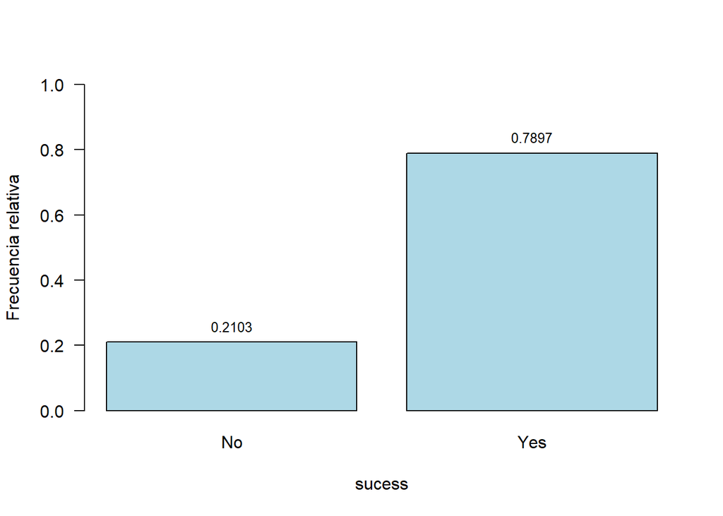

```r
#Creo la tabla de contigencia
tabla_varObj_property <- data.frame(target = datos_Mod_es1$varObj, property = datos_Mod_es1$fe_fe_property)

tabla_varObj_property$property <- as.factor(tabla_varObj_property$property)
tabla1 <- table(tabla_varObj_property$target, tabla_varObj_property$property)
#Gráfico de la variable objetivo

tabla_prop <- prop.table(tabla1, margin=2)
grafico_sucess <- barplot(tabla_prop[,1],
        beside = TRUE, las=1,
        xlab='sucess', ylab='Frecuencia relativa',
        col = c("lightblue"),
        ylim = c(0, 1))
text(x=grafico_sucess, y=tabla_prop[,1], pos=3, cex=0.8, col="black",
     label=round(tabla_prop[,1], 4))
```

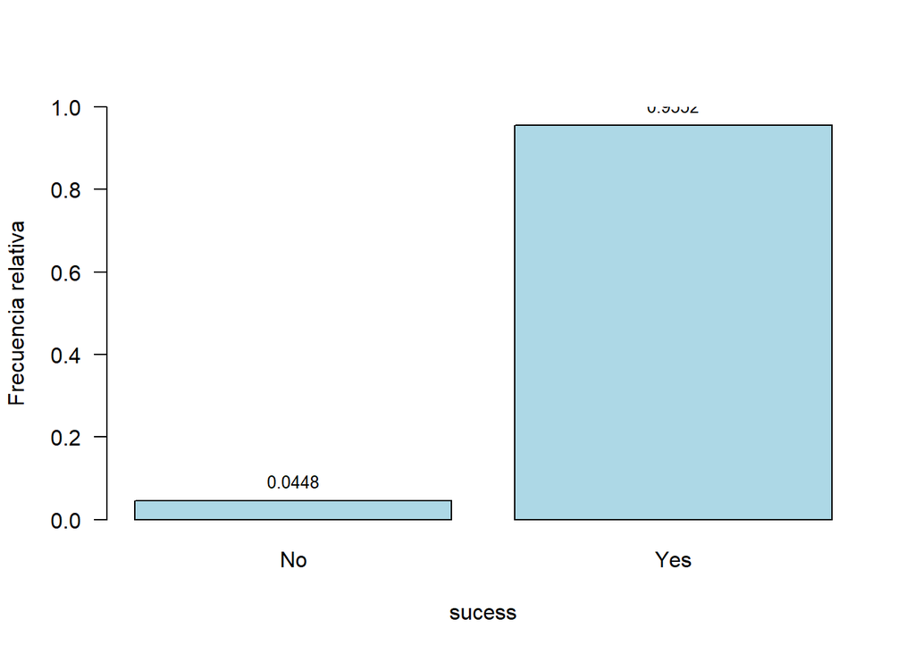

```r
#Gráfico de la variable property
grafico_property <- barplot(tabla_prop[,2],
        beside = TRUE, las=1,
        xlab='sucess', ylab='Frecuencia relativa',
        col = c("lightblue"),
        ylim = c(0, 1))
text(x=grafico_property, y=tabla_prop[,2], pos=3, cex=0.8, col="black",
     label=round(tabla_prop[,2], 4))
```

A continuación, voy a **realizar** los **contrastes** de hipótesis **adecuados** para la igualdad de distribuciones.

**Antes** de contratar la igualdad de distribuciones, debemos saber **si** estas dos variables son **independientes**.

a.- *Contraste de Independecia de Pearson*:

*H0: Las dos variables son independientes* *H1: Las dos variables son dependientes*

```r
#Creo la tabla de contigencia
tabla_varObj_property <- data.frame(target = datos_Mod_es1$varObj, property = datos_Mod_es1$fe_fe_property)

tabla_varObj_property$property <- as.factor(tabla_varObj_property$property)
tabla1 <- table(tabla_varObj_property$target, tabla_varObj_property$property)
#Realizo el contraste de la Chi-cuadrado de Pearson
chisq.test(x = tabla1)
```

```
##
##  Pearson's Chi-squared test with Yates' continuity correction
##
## data:  tabla1
## X-squared = 12663, df = 1, p-value < 2.2e-16
```

Como vemos el **p-valor** es **menor** que **0.05**, por lo tanto, los datos muestran evidencia en contra de la independencia entre las dos variables. Es decir, son **datos dependientes**.

Y además, las dos varibles son dicotómicas, por lo que no podemos hacer el contraste de los rangos con signo de Wilcoxon, ni de Friedman.

b.- *Contraste de Mc Nemar*

Las dos variables a analizar son dicotómicas y dependientes. Así pues, para poder estudiar si la distribución de ambas variables es la misma, me basaré en el contraste de Mc Nemar. Se utiliza para determinar **si existe una diferencia estadísticamente significativa en las proporciones** entre los datos emparejados

- Condiciones:
  - Se trata de datos dependientes.
  - Se estudian dos variables, ambas de tipo binomial (dicotómicas).
  - La suma de eventos que pasan de positivo a negativo y de negativo a positivo ha de ser > 25.

```r
mcnemar.test(tabla1)
```

```
##
##  McNemar's Chi-squared test with continuity correction
##
## data:  tabla1
## McNemar's chi-squared = 48873, df = 1, p-value < 2.2e-16
```

```r
#Elimino fe_fe_property de escenario 1 y 2
datos_Mod_es1$fe_fe_property <- NULL
datos_Mod_es2$fe_fe_property <- NULL
```

- **Análisis entre la variable objetivo y “fe_extended”**

a.- *Contraste de Independecia de Pearson*:

*H0: Las dos variables son independientes* *H1: Las dos variables son dependientes*

```r
#Creo la tabla de contigencia
tabla_varObj_extended <- data.frame(target = datos_Mod_es1$varObj, extended = datos_Mod_es1$fe_extended)

tabla_varObj_extended$extended <- as.factor(tabla_varObj_extended$extended)
tabla2 <- table(tabla_varObj_extended$target, tabla_varObj_extended$extended)
#Realizo el contraste de la Chi-cuadrado de Pearson
chisq.test(x = tabla2)
```

```
##
##  Pearson's Chi-squared test with Yates' continuity correction
##
## data:  tabla2
## X-squared = 1114.8, df = 1, p-value < 2.2e-16
```

Con un **nivel** de confianza del **95%**, podemos decir que las **variables** son **dependientes**.

b.- *Contraste de Mc Nemar*

```r
mcnemar.test(tabla2)
```

```
##
##  McNemar's Chi-squared test with continuity correction
##
## data:  tabla2
## McNemar's chi-squared = 160615, df = 1, p-value < 2.2e-16
```

```r
#Elimino fe_extended de escenario 1 y 2
datos_Mod_es1$fe_extended <- NULL
datos_Mod_es2$fe_extended <- NULL
```

- **Análisis entre la variable objetivo y “fe_crit1”**

a.- *Contraste de Independecia de Pearson*:

*H0: Las dos variables son independientes* *H1: Las dos variables son dependientes*

```r
#Creo la tabla de contigencia
tabla_varObj_crit1 <- data.frame(target = datos_Mod_es1$varObj, crit1 = datos_Mod_es1$fe_crit1)

tabla_varObj_crit1$crit1 <- as.factor(tabla_varObj_crit1$crit1)
tabla3 <- table(tabla_varObj_crit1$target, tabla_varObj_crit1$crit1)
#Realizo el contraste de la Chi-cuadrado de Pearson
chisq.test(x = tabla3)
```

```
##
##  Pearson's Chi-squared test with Yates' continuity correction
##
## data:  tabla3
## X-squared = 20.781, df = 1, p-value = 5.148e-06
```

Con un **nivel** de confianza del **95%**, podemos decir que las **variables** son **dependientes**.

b.- *Contraste de Mc Nemar*

```r
mcnemar.test(tabla3)
```

```
##
##  McNemar's Chi-squared test with continuity correction
##
## data:  tabla3
## McNemar's chi-squared = 16081, df = 1, p-value < 2.2e-16
```

```r
#Elimino fe_crit1 de escenario 1 y 2
datos_Mod_es1$fe_crit1 <- NULL
datos_Mod_es2$fe_crit1 <- NULL
```

- **Análisis entre la variable objetivo y “fe_crit2”**

a.- *Contraste de Independecia de Pearson*:

*H0: Las dos variables son independientes* *H1: Las dos variables son dependientes*

```r
#Creo la tabla de contigencia
tabla_varObj_crit2 <- data.frame(target = datos_Mod_es1$varObj, crit2 = datos_Mod_es1$fe_crit2)
tabla_varObj_crit2$crit2 <- as.factor(tabla_varObj_crit2$crit2)
tabla4 <- table(tabla_varObj_crit2$target, tabla_varObj_crit2$crit2)
#Realizo el contraste de la Chi-cuadrado de Pearson
chisq.test(x = tabla4)
```

```
##
##  Pearson's Chi-squared test with Yates' continuity correction
##
## data:  tabla4
## X-squared = 37.824, df = 1, p-value = 7.74e-10
```

Con un **nivel** de confianza del **95%**, las variables son **dependientes**.

b.- *Contraste de Mc Nemar*

```r
mcnemar.test(tabla4)
```

```
##
##  McNemar's Chi-squared test with continuity correction
##
## data:  tabla4
## McNemar's chi-squared = 18144, df = 1, p-value < 2.2e-16
```

```r
#Elimino fe_crit2 de escenario 1 y 2
datos_Mod_es1$fe_crit2 <- NULL
datos_Mod_es2$fe_crit2 <- NULL
```

- **Análisis entre la variable objetivo y “fe_crit3”**

a.- *Contraste de Independecia de Pearson*:

*H0: Las dos variables son independientes* *H1: Las dos variables son dependientes*

```r
#Creo la tabla de contigencia
tabla_varObj_crit3 <- data.frame(target = datos_Mod_es1$varObj, crit3 = datos_Mod_es1$fe_crit3)
tabla_varObj_crit3$crit3 <- as.factor(tabla_varObj_crit3$crit3)
tabla5 <- table(tabla_varObj_crit3$target, tabla_varObj_crit3$crit3)
#Realizo el contraste de la Chi-cuadrado de Pearson
chisq.test(x = tabla5)
```

```
##
##  Pearson's Chi-squared test with Yates' continuity correction
##
## data:  tabla5
## X-squared = 14.685, df = 1, p-value = 0.000127
```

Con un **nivel** de confianza del **95%**, las variables son **dependientes**.

b.- *Contraste de Mc Nemar*

```r
mcnemar.test(tabla5)
```

```
##
##  McNemar's Chi-squared test with continuity correction
##
## data:  tabla5
## McNemar's chi-squared = 175.39, df = 1, p-value < 2.2e-16
```

```r
#Elimino fe_crit3 de escenario 1 y 2
datos_Mod_es1$fe_crit3 <- NULL
datos_Mod_es2$fe_crit3 <- NULL
```

- **Análisis entre la variable objetivo y “fe_multiple”**

a.- *Contraste de Independecia de Pearson*:

*H0: Las dos variables son independientes* *H1: Las dos variables son dependientes*

```r
#Creo la tabla de contigencia
tabla_varObj_multiple <- data.frame(target = datos_Mod_es1$varObj, multiple = datos_Mod_es1$fe_multiple)
tabla_varObj_multiple$multiple <- as.factor(tabla_varObj_multiple$multiple)
tabla6 <- table(tabla_varObj_multiple$target, tabla_varObj_multiple$multiple)
#Realizo el contraste de la Chi-cuadrado de Pearson
chisq.test(x = tabla6)
```

```
##
##  Pearson's Chi-squared test with Yates' continuity correction
##
## data:  tabla6
## X-squared = 80.379, df = 1, p-value < 2.2e-16
```

Con un **nivel** de confianza del **95%**, las variables son **dependientes**.

b.- *Contraste de Mc Nemar*

```r
mcnemar.test(tabla6)
```

```
##
##  McNemar's Chi-squared test with continuity correction
##
## data:  tabla6
## McNemar's chi-squared = 138101, df = 1, p-value < 2.2e-16
```

```r
#Elimino fe_multiple de escenario 1 y 2
datos_Mod_es1$fe_multiple <- NULL
datos_Mod_es2$fe_multiple<- NULL
```

- **Análisis entre la variable objetivo y “fe_suicide”**

a.- *Contraste de Independecia de Pearson*:

*H0: Las dos variables son independientes* *H1: Las dos variables son dependientes*

```r
#Creo la tabla de contigencia
tabla_varObj_suicide <- data.frame(target = datos_Mod_es1$varObj, suicide = datos_Mod_es1$fe_suicide)
tabla_varObj_suicide$suicide <- as.factor(tabla_varObj_suicide$suicide)
tabla7 <- table(tabla_varObj_suicide$target, tabla_varObj_suicide$suicide)
#Realizo el contraste de la Chi-cuadrado de Pearson
chisq.test(x = tabla7)
```

```
##
##  Pearson's Chi-squared test with Yates' continuity correction
##
## data:  tabla7
## X-squared = 175.61, df = 1, p-value < 2.2e-16
```

Con un **nivel** de confianza del **95%**, las variables son **dependientes**.

b.- *Contraste de Mc Nemar*

```r
mcnemar.test(tabla7)
```

```
##
##  McNemar's Chi-squared test with continuity correction
##
## data:  tabla7
## McNemar's chi-squared = 160535, df = 1, p-value < 2.2e-16
```

```r
#Elimino fe_suicide de escenario 1 y 2
datos_Mod_es1$fe_suicide <- NULL
datos_Mod_es2$fe_suicide<- NULL
```

- **Análisis entre la variable objetivo y “fe_individual”**

a.- *Contraste de Independecia de Pearson*:

*H0: Las dos variables son independientes* *H1: Las dos variables son dependientes*

```r
#Creo la tabla de contigencia
tabla_varObj_individual <- data.frame(target = datos_Mod_es1$varObj, individual = datos_Mod_es1$fe_individual)
tabla_varObj_individual$individual <- as.factor(tabla_varObj_individual$individual)
tabla8 <- table(tabla_varObj_individual$target, tabla_varObj_individual$individual)
#Realizo el contraste de la Chi-cuadrado de Pearson
chisq.test(x = tabla8)
```

```
##
##  Pearson's Chi-squared test with Yates' continuity correction
##
## data:  tabla8
## X-squared = 61.796, df = 1, p-value = 3.809e-15
```

Con un **nivel** de confianza del **95%**, las variables son **dependientes**.

b.- *Contraste de Mc Nemar*

```r
mcnemar.test(tabla8)
```

```
##
##  McNemar's Chi-squared test with continuity correction
##
## data:  tabla8
## McNemar's chi-squared = 168839, df = 1, p-value < 2.2e-16
```

```r
#Elimino fe_suicide de escenario 1 y 2
datos_Mod_es1$fe_individual <- NULL
datos_Mod_es2$fe_individual<- NULL
```

- **Análisis entre la variable objetivo y “fe_fe_doubtterr”**

a.- *Contraste de Independecia de Pearson*:

*H0: Las dos variables son independientes* *H1: Las dos variables son dependientes*

```r
#Creo la tabla de contigencia
tabla_varObj_doubtterr <- data.frame(target = datos_Mod_es1$varObj, doubtterr = datos_Mod_es1$fe_fe_doubtterr)
tabla_varObj_doubtterr$doubtterr <- as.factor(tabla_varObj_doubtterr$doubtterr)
tabla9 <- table(tabla_varObj_doubtterr$target, tabla_varObj_doubtterr$doubtterr)
#Realizo el contraste de la Chi-cuadrado de Pearson
chisq.test(x = tabla9)
```

```
##
##  Pearson's Chi-squared test with Yates' continuity correction
##
## data:  tabla9
## X-squared = 68.916, df = 1, p-value < 2.2e-16
```

Con un **nivel** de confianza del **95%**, las variables son **dependientes**.

b.- *Contraste de Mc Nemar*

```r
mcnemar.test(tabla9)
```

```
##
##  McNemar's Chi-squared test with continuity correction
##
## data:  tabla9
## McNemar's chi-squared = 132766, df = 1, p-value < 2.2e-16
```

```r
#Elimino fe_suicide de escenario 1 y 2
datos_Mod_es1$fe_fe_doubtterr <- NULL
datos_Mod_es2$fe_fe_doubtterr<- NULL
```

- **Análisis entre la variable objetivo y “fe_fe_INT_MISC”**

a.- *Contraste de Independecia de Pearson*:

*H0: Las dos variables son independientes* *H1: Las dos variables son dependientes*

```r
#Creo la tabla de contigencia
tabla_varObj_INT_MISC <- data.frame(target = datos_Mod_es1$varObj, INT_MISC = datos_Mod_es1$fe_fe_INT_MISC)
tabla_varObj_INT_MISC$INT_MISC <- as.factor(tabla_varObj_INT_MISC$INT_MISC)
tabla10 <- table(tabla_varObj_INT_MISC$target, tabla_varObj_INT_MISC$INT_MISC)
#Realizo el contraste de la Chi-cuadrado de Pearson
chisq.test(x = tabla10)
```

```
##
##  Pearson's Chi-squared test with Yates' continuity correction
##
## data:  tabla10
## X-squared = 190.22, df = 1, p-value < 2.2e-16
```

Con un **nivel** de confianza del **95%**, las variables son **dependientes**.

b.- *Contraste de Mc Nemar*

```r
mcnemar.test(tabla10)
```

```
##
##  McNemar's Chi-squared test with continuity correction
##
## data:  tabla10
## McNemar's chi-squared = 142540, df = 1, p-value < 2.2e-16
```

```r
#Elimino fe_suicide de escenario 1 y 2
datos_Mod_es1$fe_fe_INT_MISC <- NULL
datos_Mod_es2$fe_fe_INT_MISC<- NULL
```

- **Análisis entre la variable objetivo y “fe_fe_ishostkid”**

a.- *Contraste de Independecia de Pearson*:

*H0: Las dos variables son independientes* *H1: Las dos variables son dependientes*

```r
#Creo la tabla de contigencia
tabla_varObj_ishostkid <- data.frame(target = datos_Mod_es1$varObj, ishostkid = datos_Mod_es1$fe_fe_ishostkid)
tabla_varObj_ishostkid$ishostkid <- as.factor(tabla_varObj_ishostkid$ishostkid)
tabla11 <- table(tabla_varObj_ishostkid$target, tabla_varObj_ishostkid$ishostkid)
#Realizo el contraste de la Chi-cuadrado de Pearson
chisq.test(x = tabla11)
```

```
##
##  Pearson's Chi-squared test with Yates' continuity correction
##
## data:  tabla11
## X-squared = 1659.4, df = 1, p-value < 2.2e-16
```

Con un **nivel** de confianza del **95%**, las variables son **dependientes**.

b.- *Contraste de Mc Nemar*

```r
mcnemar.test(tabla11)
```

```
##
##  McNemar's Chi-squared test with continuity correction
##
## data:  tabla11
## McNemar's chi-squared = 154549, df = 1, p-value < 2.2e-16
```

```r
#Elimino fe_suicide de escenario 1 y 2
datos_Mod_es1$fe_fe_ishostkid <- NULL
datos_Mod_es2$fe_fe_ishostkid<- NULL
```

- **Análisis entre la variable objetivo y “fe_fe_vicinity”**

a.- *Contraste de Independecia de Pearson*:

*H0: Las dos variables son independientes* *H1: Las dos variables son dependientes*

```r
#Creo la tabla de contigencia
tabla_varObj_vicinity <- data.frame(target = datos_Mod_es1$varObj, vicinity = datos_Mod_es1$fe_fe_vicinity)
tabla_varObj_vicinity$vicinity <- as.factor(tabla_varObj_vicinity$vicinity)
tabla12 <- table(tabla_varObj_vicinity$target, tabla_varObj_vicinity$vicinity)
#Realizo el contraste de la Chi-cuadrado de Pearson
chisq.test(x = tabla12)
```

```
##
##  Pearson's Chi-squared test with Yates' continuity correction
##
## data:  tabla12
## X-squared = 0.043417, df = 1, p-value = 0.8349
```

Con un **nivel** de confianza del **95%**, las variables son **independientes**.

b.- *Test exacto de Fisher*

Condiciones del test:

- Independencia: las observaciones de la muestra deben ser independientes unas de otras.
- Muestreo aleatorio.
- Tamaño de la muestra < 10% población.

Cada observación contribuye únicamente a uno de los niveles.

```r
fisher.test(x = tabla12, alternative = "two.sided")
```

```
##
##  Fisher's Exact Test for Count Data
##
## data:  tabla12
## p-value = 0.822
## alternative hypothesis: true odds ratio is not equal to 1
## 95 percent confidence interval:
##  0.9404369 1.0506624
## sample estimates:
## odds ratio
##  0.9937763
```

Con un **nivel** de confianza del **95%**, podemos decir que estas dos variables **no** tienen la **misma distribución**.

A continuación, **guardo** las dos **bases de datos** para posteriormente, empezar con la fase de Modelización.

```r
#Guardo los dataset del escenario 1, depurados para la fase de modelización
fwrite(datos_Mod_es1, 'datos_escenario1_atentados.csv')

#Guardo los dataset del escenario 2, depurados para la fase de modelización
fwrite(datos_Mod_es2, 'datos_escenario2_atentados.csv')
```